# PFAS Modeling – Michigan PFAS Dashboard

**Modeling Question** Which public water systems in Michigan are most at risk of PFAS contamination, and how do distance to known PFAS sites, aquifer type and soil permeability explain it?

**Key decisions**

| Decision | Choice | Why |
| --- | --- | --- |
| Unit of analysis | Water system, using its worst location (`max_hazard`) | A public-health read should not let clean samples average away a hotspot |
| Outcome | `log(1 + max_hazard)` for linear models; raw `max_hazard` for Tweedie | 86% of readings are exactly zero and the rest are right-skewed |
| Distance | `log(1 + distance)` to the nearest known PFAS site, no cap; for the extended models taken from the system’s highest-Hazard-Index location (`DISTANCE_BASIS`) | Uses the full range; the log compresses the long tail; same spot as the aquifer and soil |
| Soil | Permeability (harmonic mean of `ksat` over the top 100 cm, weighted by component percent, log10 scale) plus drainage class, hydrologic group, water table and bedrock depth, slope, organic carbon, avai… | Layers act in series, and permeability spans orders of magnitude; the selection decides which other soil variables matter |
| Model order | Baseline, then zero-inflated Tweedie, then hurdle | Simple to flexible; each is compared on the same systems |
| Variable selection | Automatic backward elimination over all candidates, soil included; `n_hex_ids` always kept | AIC and BIC both run; the criterion used downstream is chosen automatically (BIC when there are fewer than 20 detected systems per candidate variable); `SELECTION_MODE` can force one |
| Rows | Systems with an aquifer match and a permeability value | AIC/BIC need every candidate model on the same rows |

**Packages used:** tidyverse, janitor, sf, tidymodels, glmmTMB (Tweedie), glmnet (LASSO), terra (soil map, first run only) and spdep (optional spatial check).

```
Rows: 1,388
Columns: 6
$ OBJECTID   <int> 1, 2, 3, 4, 5, 6, 7, 8, 9, 10, 11, 12, 13, 14, 15, 16, 17, …
$ AQU_UNIT   <chr> "1", "4", "4", "4", "1", "1", "1", "1", "1", "3b", "1", "3b…
$ AQU_CHAR   <chr> "I - Thin drift (0-30 feet) overlying bedrock", "IV - Drift…
$ ShapeSTAre <dbl> 30559525, 34926597, 39231815, 70670398, 92834455, 43694538,…
$ ShapeSTLen <dbl> 48791.43, 28976.88, 31178.42, 52638.60, 42974.16, 28128.51,…
$ geometry   <MULTIPOLYGON [m]> MULTIPOLYGON (((162658 6751..., MULTIPOLYGON (…
```

```
Rows: 262,304
Columns: 44
$ geoid                      <dbl> 26129, 26129, 26129, 26129, 26129, 26129, 2…
$ longitude.x                <dbl> -84.09276, -84.09276, -84.09276, -84.09276,…
$ latitude.x                 <dbl> 44.18548, 44.18548, 44.18548, 44.18548, 44.…
$ object_id                  <dbl> 1090, 1090, 1090, 1090, 1090, 1090, 1090, 1…
$ hex_id                     <dbl> 1, 1, 1, 1, 1, 1, 1, 1, 1, 1, 1, 1, 1, 1, 1…
$ system_name                <chr> "Cole Canoe Base", "Cole Canoe Base", "Cole…
$ wssn                       <dbl> 2004765, 2004765, 2004765, 2004765, 2004765…
$ system_type                <chr> "CHLCMP", "CHLCMP", "CHLCMP", "CHLCMP", "CH…
$ loc_name                   <chr> "LOC03", "LOC03", "LOC03", "LOC03", "LOC03"…
$ sys_loc_code               <chr> "CHLCMP-038-LOC03", "CHLCMP-038-LOC03", "CH…
$ position_source            <chr> "EGLE", "EGLE", "EGLE", "EGLE", "EGLE", "EG…
$ phase_code                 <chr> "PHASE_2", "PHASE_2", "PHASE_2", "PHASE_2",…
$ task_code                  <chr> "PHASE_2", "PHASE_2", "PHASE_2", "PHASE_2",…
```

[output cut: 31 more lines]

```
Rows: 145,692
Columns: 26
$ geoid                  <dbl> NA, NA, NA, NA, NA, NA, NA, NA, NA, NA, NA, NA,…
$ longitude              <dbl> -83.31704, -83.31704, -83.31704, -83.31704, -83…
$ latitude               <dbl> 44.40617, 44.40617, 44.40617, 44.40617, 44.4061…
$ lab_sample_id          <chr> "2209071-18", "2209071-18", "2209071-18", "2209…
$ site_code              <chr> "02-As-0001", "02-As-0001", "02-As-0001", "02-A…
$ coc_sample_id          <chr> "As-0011 D.c.", "As-0011 D.c.", "As-0011 D.c.",…
$ sample_type            <chr> "Depth Integrated", "Depth Integrated", "Depth …
$ lab_name               <chr> "Egle", "Egle", "Egle", "Egle", "Egle", "Egle",…
$ lab_job_name           <chr> "2209071", "2209071", "2209071", "2209071", "22…
$ collection_date        <chr> "2022/09/08 00:00:00+00", "2022/09/08 00:00:00+…
$ analysis_method        <chr> "Pfas-8327", "Pfas-8327", "Pfas-8327", "Pfas-83…
$ dilution_factor        <dbl> 1, 1, 1, 1, 1, 1, 1, 1, 1, 1, 1, 1, 1, 1, 1, 1,…
$ analysis_date          <chr> "2022/09/14 00:00:00+00", "2022/09/14 00:00:00+…
$ duplicate              <dbl> 3, 3, 3, 3, 3, 3, 3, 3, 3, 3, 3, 3, 3, 3, 3, 1,…
$ watershed              <chr> "Au Sable", "Au Sable", "Au Sable", "Au Sable",…
$ waterbody              <chr> "Au Sable River", "Au Sable River", "Au Sable R…
$ location_code          <chr> "As-0001", "As-0001", "As-0001", "As-0001", "As…
$ huc10                  <chr> "0407000705", "0407000705", "0407000705", "0407…
$ huc8                   <chr> "04070007", "04070007", "04070007", "04070007",…
$ project                <chr> "Investigative", "Investigative", "Investigativ…
$ description            <chr> "Au Sable @ Lake Huron Pier", "Au Sable @ Lake …
$ additional_description <chr> NA, NA, NA, NA, NA, NA, NA, NA, NA, NA, NA, NA,…
$ visit_id               <dbl> 2022020, 2022020, 2022020, 2022020, 2022020, 20…
$ sample_depth           <chr> "Integrated", "Integrated", "Integrated", "Inte…
$ analyte                <chr> "CAS13252136_GenX", "CAS13252136_GenXMdl", "CAS…
$ analyte_value          <dbl> 4.0, 0.9, 4.0, 0.0, 0.0, 0.0, 1.7, 0.7, 2.0, 2.…
```

```
Rows: 45,080
Columns: 26
$ geoid                  <dbl> 26129, 26129, 26129, 26129, 26129, 26129, 26129…
$ longitude              <dbl> -84.09276, -84.09276, -84.09276, -84.09276, -84…
$ latitude               <dbl> 44.18548, 44.18548, 44.18548, 44.18548, 44.1854…
$ object_id              <dbl> 1090, 1090, 1090, 1090, 1090, 1090, 1090, 1090,…
$ hex_id                 <dbl> 1, 1, 1, 1, 1, 1, 1, 1, 1, 1, 1, 1, 1, 1, 1, 1,…
$ system_name            <chr> "Cole Canoe Base", "Cole Canoe Base", "Cole Can…
$ wssn                   <dbl> 2004765, 2004765, 2004765, 2004765, 2004765, 20…
$ system_type            <chr> "Non-Community Water Supply (Children's Camp)",…
$ loc_name               <chr> "LOC03", "LOC03", "LOC03", "LOC03", "LOC03", "L…
$ sys_loc_code           <chr> "CHLCMP-038-LOC03", "CHLCMP-038-LOC03", "CHLCMP…
$ position_source        <chr> "EGLE", "EGLE", "EGLE", "EGLE", "EGLE", "EGLE",…
$ phase_code             <chr> "PHASE_2", "PHASE_2", "PHASE_2", "PHASE_2", "PH…
$ task_code              <chr> "PHASE_2", "PHASE_2", "PHASE_2", "PHASE_2", "PH…
$ task_type              <chr> "StateSurv", "StateSurv", "StateSurv", "StateSu…
$ sample_date            <chr> "2019/06/12 00:00:00+00", "2019/06/12 00:00:00+…
$ treatment_status       <chr> "Raw", "Raw", "Raw", "Raw", "Raw", "Raw", "Raw"…
$ sys_sample_code        <chr> "GWIN1906121350RL", "GWIN1906121350RL", "GWIN19…
$ lab_name_code          <chr> "VAL", "VAL", "VAL", "VAL", "VAL", "VAL", "VAL"…
$ lab_number             <chr> NA, NA, NA, NA, NA, NA, NA, NA, NA, NA, NA, NA,…
$ lab_sdg                <chr> "1901633", "1901633", "1901633", "1901633", "19…
$ analytical_method      <chr> "EPA-537", "EPA-537", "EPA-537", "EPA-537", "EP…
$ sampling_results_count <dbl> 5, 5, 5, 5, 5, 5, 5, 5, 5, 5, 5, 5, 5, 5, 5, 5,…
$ Hazard_Index           <dbl> 0, 0, 0, 0, 0, 0, 0, 0, 0, 0, 0, 0, 0, 0, 0, 0,…
$ analyte                <chr> "HFPODA", "PFBS", "PFHxA", "PFHxS", "PFNA", "PF…
$ analyte_value          <dbl> 0, 0, 0, 0, 0, 0, 0, 0, 0, 0, 0, 0, 0, 0, 0, 0,…
$ system_short           <chr> "CHLCMP", "CHLCMP", "CHLCMP", "CHLCMP", "CHLCMP…
```

```
Rows: 300
Columns: 20
$ geoid                      <dbl> 26081, 26081, 26039, 26103, 26069, 26087, 2…
$ longitude                  <dbl> -85.62169, -85.56018, -84.78779, -87.38730,…
$ latitude                   <dbl> 43.10536, 43.12251, 44.62668, 46.34960, 44.…
$ facility                   <chr> "Belmont - House St.", "Rockford Tannery", …
$ county                     <chr> "Kent County", "Kent County", "Crawford Cou…
$ address                    <chr> "1855 House Street", "123 North Main Street…
$ city                       <chr> "Rockford", "Rockford", "Grayling", "Gwinn"…
$ zip_code                   <dbl> 49341, 49341, 49738, 49841, 48750, 48446, 4…
$ type                       <chr> "Landfill", "Tannery", "Military", "Militar…
$ residential_wells_sampled  <chr> "Yes", "No", "Yes", "Yes", "Yes", "No", "No…
$ site_lead                  <chr> "Leah Gies", "Leah Gies", "Lisa Kruse", "Ke…
$ site_lead_email            <chr> "giesl1@michigan.gov", "giesl1@michigan.gov…
$ site_lead_phone            <chr> "616-215-4781", "616-215-4781", "989-370-14…
$ hyperlink                  <chr> "https://www.michigan.gov/pfasresponse/inve…
$ location                   <chr> "Rockford", "Rockford", "Grayling", "Gwinn"…
$ military                   <chr> "No", "No", "Yes", "Yes", "Yes", "No", "No"…
$ facility_date              <chr> NA, NA, NA, "2017/10/31 16:00:00+00", "2019…
$ site_background            <chr> NA, NA, NA, NA, NA, NA, NA, NA, NA, NA, NA,…
$ drinking_water_information <chr> NA, NA, NA, NA, NA, NA, NA, NA, NA, NA, NA,…
$ anticipated_activities     <chr> NA, NA, NA, NA, NA, NA, NA, NA, NA, NA, NA,…
```

The soil data is the Michigan gSSURGO geodatabase (`gSSURGO_MI.gdb`) from USDA-NRCS, downloaded from the [NRCS gSSURGO Box folder](https://nrcs.app.box.com/v/soils/folder/233398887779?page=2). The geodatabase has only **one map layer** (`MUPOLYGON`, the soil map). Every soil property sits in separate tables that link to it by key, so the polygons themselves carry IDs and no soil values.

```
Driver: OpenFileGDB
Available layers:
           layer_name     geometry_type features fields             crs_name
1            chaashto                NA   323024      4                 <NA>
2       chconsistence                NA    70267     10                 <NA>
3       chdesgnsuffix                NA    83893      3                 <NA>
4             chfrags                NA   314856     12                 <NA>
5            chorizon                NA   165958    171                 <NA>
6             chpores                NA        0      9                 <NA>
7            chstruct                NA   190762      7                 <NA>
8         chstructgrp                NA   169850      4                 <NA>
9              chtext                NA        0      7                 <NA>
10          chtexture                NA   363044      4                 <NA>
11       chtexturegrp                NA   351939      6                 <NA>
12       chtexturemod                NA    53683      3                 <NA>
```

[output cut: 66 more lines]

The geodatabase has 78 layers, some have geometry type as NA meaning there is a plain table with no map shape that is no mupolygon also some have crs NA because the tables are non map

```
Rows: 1,000
Columns: 7
$ AREASYMBOL   <chr> "MI606", "MI606", "MI606", "MI606", "MI606", "MI606", "MI…
$ SPATIALVER   <dbl> 6, 6, 6, 6, 6, 6, 6, 6, 6, 6, 6, 6, 6, 6, 6, 6, 6, 6, 6, …
$ MUSYM        <chr> "19", "19", "19", "19", "19", "19", "19", "19", "19", "19…
$ MUKEY        <chr> "1717914", "1717914", "1717914", "1717914", "1717914", "1…
$ Shape_Length <dbl> 4222.9861, 795.2948, 590.5845, 1384.1306, 917.1329, 1360.…
$ Shape_Area   <dbl> 412646.420, 29920.250, 19592.355, 35826.930, 29737.050, 6…
$ Shape        <MULTIPOLYGON [m]> MULTIPOLYGON (((528380.3 27..., MULTIPOLYGON…
```

```
# A tibble: 6 × 2
  layer_name features
  <chr>         <dbl>
1 chorizon     165958
2 component     36240
3 mapunit       10664
4 muaggatt      10664
5 MUPOLYGON   1207754
6 Valu1         10664
```

| Table | Rows | One row represents | Key fields | Used for | Importance |
| --- | --- | --- | --- | --- | --- |
| `MUPOLYGON` | 1,207,754 | A soil map polygon (a shape on the map) | `MUKEY` | Matching each sampling location to a soil map unit, and drawing the soil map | Essential |
| `mapunit` | 10,664 | A soil map unit (a named group of soils) | `mukey` | Reference names only; no model variable comes from it | Low |
| `muaggatt` | 10,664 | A map unit, with ready-made summaries | `mukey` | Drainage class, hydrologic group, water table depth, bedrock depth, slope | High |
| `Valu1` | 10,664 | A map unit, with pre-computed values | `mukey` | Organic carbon, available water storage, droughty flag | Medium |
| `component` | 36,240 | A soil type inside a map unit | `mukey`, `cokey`, `comppct_r` | Linking map units to soil layers; `comppct_r` (percent of the map unit) is the weight when averaging | High |
| `chorizon` | 165,958 | A soil layer (horizon) of a soil type | `cokey`, `ksat_r`, `hzdept_r`, `hzdepb_r` | The only source of permeability (`ksat_r`) | High |

The tables connect in one chain: a sampling location falls inside a `MUPOLYGON` polygon, which gives its `MUKEY`. `muaggatt`, `Valu1` and `mapunit` have one row per `MUKEY`, so they join directly. Permeability takes extra steps: `chorizon` layers (linked by `cokey`) roll up to `component`, then to the map unit. About 1.2 million polygons point to only about 10,000 distinct map units, so many polygons share the same soil properties.

```
Rows: 10,664
Columns: 25
$ musym         <chr> "10C", "10D", "11E", "12E", "11D", "13E", "13D", "13F", …
$ muname        <chr> "Minong-Quetico-Rock outcrop complex, 2 to 14 percent sl…
$ mukind        <chr> "Complex", "Complex", "Complex", "Consociation", "Comple…
$ mustatus      <chr> NA, NA, NA, NA, NA, NA, NA, NA, NA, NA, NA, NA, NA, NA, …
$ muacres       <int> 132, 467, 1946, 2516, 3476, 4440, 7807, 1375, 523, 1511,…
$ mapunitlfw_l  <int> NA, NA, NA, NA, NA, NA, NA, NA, NA, NA, NA, NA, NA, NA, …
$ mapunitlfw_r  <int> NA, NA, NA, NA, NA, NA, NA, NA, NA, NA, NA, NA, NA, NA, …
$ mapunitlfw_h  <int> NA, NA, NA, NA, NA, NA, NA, NA, NA, NA, NA, NA, NA, NA, …
$ mapunitpfa_l  <dbl> 0.1, 0.1, 0.1, NA, 0.1, NA, NA, NA, NA, NA, NA, NA, NA, …
$ mapunitpfa_r  <dbl> 0.2, 0.2, 0.2, NA, 0.2, NA, NA, NA, NA, NA, NA, NA, NA, …
$ mapunitpfa_h  <dbl> 0.3, 0.3, 0.3, NA, 0.3, NA, NA, NA, NA, NA, NA, NA, NA, …
$ farmlndcl     <chr> NA, NA, NA, NA, NA, NA, NA, NA, NA, NA, NA, NA, NA, NA, …
$ muhelcl       <chr> NA, NA, NA, NA, NA, NA, NA, NA, NA, NA, NA, NA, NA, NA, …
$ muwathelcl    <chr> NA, NA, NA, NA, NA, NA, NA, NA, NA, NA, NA, NA, NA, NA, …
$ muwndhelcl    <chr> NA, NA, NA, NA, NA, NA, NA, NA, NA, NA, NA, NA, NA, NA, …
$ interpfocus   <chr> NA, NA, NA, NA, NA, NA, NA, NA, NA, NA, NA, NA, NA, NA, …
$ invesintens   <chr> "Order 2", "Order 2", "Order 2", "Order 2", "Order 2", "…
$ iacornsr      <int> NA, NA, NA, NA, NA, NA, NA, NA, NA, NA, NA, NA, NA, NA, …
$ nhiforsoigrp  <chr> NA, NA, NA, NA, NA, NA, NA, NA, NA, NA, NA, NA, NA, NA, …
$ nhspiagr      <dbl> NA, NA, NA, NA, NA, NA, NA, NA, NA, NA, NA, NA, NA, NA, …
$ vtsepticsyscl <chr> NA, NA, NA, NA, NA, NA, NA, NA, NA, NA, NA, NA, NA, NA, …
$ mucertstat    <chr> NA, NA, NA, NA, NA, NA, NA, NA, NA, NA, NA, NA, NA, NA, …
$ lkey          <chr> "17684", "17684", "17684", "17684", "17684", "17684", "1…
$ mukey         <chr> "1717884", "1717885", "1717886", "1717902", "1717905", "…
$ natmusym      <chr> "1vnlm", "1vnln", "1vnlp", "1vnm6", "1vnm9", "1vnmb", "1…
```

```
Rows: 10,664
Columns: 40
$ musym          <chr> "10C", "10D", "11E", "12E", "11D", "13E", "13D", "13F",…
$ muname         <chr> "Minong-Quetico-Rock outcrop complex, 2 to 14 percent s…
$ mustatus       <chr> NA, NA, NA, NA, NA, NA, NA, NA, NA, NA, NA, NA, NA, NA,…
$ slopegraddcp   <dbl> 8, 13, 20, 27, 16, 21, 13, 34, 53, 5, 10, 1, 1, 4, 4, 3…
$ slopegradwta   <dbl> 7.5, 10.8, 18.6, 27.0, 15.3, 20.0, 12.2, 33.5, 52.6, 4.…
$ brockdepmin    <int> 0, 0, 18, 45, 18, 38, 38, 38, 18, NA, NA, NA, NA, NA, N…
$ wtdepannmin    <int> NA, NA, NA, NA, NA, NA, NA, NA, NA, 30, 30, 0, 0, 0, 0,…
$ wtdepaprjunmin <int> NA, NA, NA, NA, NA, NA, NA, NA, NA, 30, 30, 0, 0, 0, 0,…
$ flodfreqdcd    <chr> "None", "None", "None", "None", "None", "None", "None",…
$ flodfreqmax    <chr> "None", "None", "None", "None", "None", "None", "None",…
$ pondfreqprs    <chr> "6", "16", "7", "0", "4", "5", "5", "1", "0", "10", "12…
$ aws025wta      <dbl> 5.20, 5.30, 4.56, 4.98, 4.51, 4.97, 4.90, 4.87, 4.23, 4…
$ aws050wta      <dbl> 5.48, 7.04, 5.85, 7.66, 5.83, 7.64, 7.72, 7.47, 5.84, 7…
```

[output cut: 27 more lines]

```
Rows: 10,664
Columns: 58
$ aws0_5     <dbl> NA, NA, 6.50, NA, NA, NA, NA, NA, NA, 3.50, NA, NA, NA, NA,…
$ aws5_20    <dbl> NA, NA, 19.50, NA, NA, NA, NA, NA, NA, 10.50, NA, NA, NA, N…
$ aws20_50   <dbl> NA, NA, 39.00, NA, NA, NA, NA, NA, NA, 21.00, NA, NA, NA, N…
$ aws50_100  <dbl> NA, NA, 65.00, NA, NA, NA, NA, NA, NA, 35.00, NA, NA, NA, N…
$ aws100_150 <dbl> NA, NA, 65.00, NA, NA, NA, NA, NA, NA, 35.00, NA, NA, NA, N…
$ aws150_999 <dbl> NA, NA, 68.90, NA, NA, NA, NA, NA, NA, 1.40, NA, NA, NA, NA…
$ aws0_20    <dbl> NA, NA, 26.00, NA, NA, NA, NA, NA, NA, 14.00, NA, NA, NA, N…
$ aws0_30    <dbl> NA, NA, 39.00, NA, NA, NA, NA, NA, NA, 21.00, NA, NA, NA, N…
$ aws0_100   <dbl> NA, NA, 130.00, NA, NA, NA, NA, NA, NA, 70.00, NA, NA, NA, …
$ aws0_150   <dbl> NA, NA, 195.00, NA, NA, NA, NA, NA, NA, 105.00, NA, NA, NA,…
$ aws0_999   <dbl> NA, NA, 263.90, NA, NA, NA, NA, NA, NA, 106.40, NA, NA, NA,…
$ tk0_5a     <dbl> NA, NA, 5, NA, NA, NA, NA, NA, NA, 5, NA, NA, NA, NA, NA, N…
$ tk5_20a    <dbl> NA, NA, 15, NA, NA, NA, NA, NA, NA, 15, NA, NA, NA, NA, NA,…
```

[output cut: 45 more lines]

```
Rows: 36,240
Columns: 109
$ comppct_l        <int> NA, NA, NA, NA, NA, NA, NA, NA, NA, NA, NA, NA, NA, N…
$ comppct_r        <int> 6, 45, 28, 21, 8, 7, 2, 2, 9, 5, 15, 32, 20, 5, 2, 2,…
$ comppct_h        <int> NA, NA, NA, NA, NA, NA, NA, NA, NA, NA, NA, NA, NA, N…
$ compname         <chr> "Nevens", "Minong", "Quetico", "Rock outcrop", "Peshe…
$ compkind         <chr> "Series", "Series", "Series", "Miscellaneous area", "…
$ majcompflag      <chr> "No ", "Yes", "Yes", "Yes", "No ", "No ", "No ", "No …
$ otherph          <chr> NA, NA, NA, NA, NA, NA, NA, NA, NA, NA, NA, NA, NA, N…
$ localphase       <chr> "very stony", "very stony", "very stony", NA, "very s…
$ slope_l          <dbl> 0, 2, 2, NA, 5, 0, 3, 5, 0, 5, NA, 5, 5, 0, 0, 6, 6, …
$ slope_r          <dbl> 1, 8, 8, NA, 13, 1, 6, 13, 3, 13, NA, 13, 13, 1, 0, 2…
$ slope_h          <dbl> 2, 14, 14, NA, 21, 2, 12, 21, 6, 21, NA, 21, 21, 1, 1…
$ slopelenusle_l   <int> 14, 18, 18, NA, 18, 14, 20, 18, 14, 18, NA, 18, 18, 1…
$ slopelenusle_r   <int> 130, 60, 60, NA, 45, 130, 90, 45, 130, 45, NA, 45, 45…
```

[output cut: 96 more lines]

```
Rows: 165,958
Columns: 171
$ hzname           <chr> "Oa", "A", "BCd", "Cd", "Bw", "2R", "Oa", "Oi", "A", …
$ desgndisc        <int> NA, NA, NA, NA, NA, 2, NA, NA, NA, 2, NA, NA, NA, 2, …
$ desgnmaster      <chr> NA, "A", "BC", "C", "B", "R", NA, NA, "A", "R", "B", …
$ desgnmasterprime <chr> NA, NA, NA, NA, NA, NA, NA, NA, NA, NA, NA, NA, NA, N…
$ desgnvert        <int> NA, NA, NA, NA, NA, NA, NA, NA, NA, NA, NA, NA, NA, N…
$ hzdept_l         <int> NA, NA, NA, NA, NA, NA, NA, NA, NA, NA, NA, NA, 0, NA…
$ hzdept_r         <int> 0, 8, 56, 79, 25, 15, 5, 0, 10, 18, 5, 0, 0, 38, 20, …
$ hzdept_h         <int> NA, NA, NA, NA, NA, NA, NA, NA, NA, NA, NA, NA, 0, NA…
$ hzdepb_l         <int> NA, NA, NA, NA, NA, NA, NA, NA, NA, NA, NA, NA, 203, …
$ hzdepb_r         <int> 8, 25, 79, 203, 56, 203, 10, 5, 15, 203, 18, 5, 203, …
$ hzdepb_h         <int> NA, NA, NA, NA, NA, NA, NA, NA, NA, NA, NA, NA, 203, …
$ hzthk_l          <int> NA, NA, NA, NA, NA, NA, NA, NA, NA, NA, NA, NA, 203, …
$ hzthk_r          <int> 8, 17, 23, 124, 31, NA, 5, 5, 5, 185, 13, 5, 203, 165…
```

[output cut: 158 more lines]

The soil tables fit together like this: `MUPOLYGON` (the map, about 1.2 million polygons) points to about 10,664 distinct map units through `MUKEY`, so many polygons share the same soil properties. `mapunit`, `muaggatt` and `Valu1` have one row per soil map unit (linked to the polygons by `mukey`), `component` has one row per soil type inside a map unit, and `chorizon` has one row per soil layer inside a component (linked by `cokey`). Permeability lives in `chorizon`.

```
# A tibble: 1 × 3
  n_locations n_missing_aquifer pct_missing
        <int>             <int>       <dbl>
1        1610                77         4.8
```

```
[1] 77
```

```
# A tibble: 77 × 3
   hex_id longitude latitude
    <dbl>     <dbl>    <dbl>
 1     14     -82.4     43.1
 2     21     -83.4     44.3
 3     30     -83.3     42.0
 4     45     -82.5     43.3
 5     64     -83.3     44.5
 6     70     -86.3     42.4
 7     74     -87.3     46.5
 8    105     -84.8     45.9
 9    122     -83.8     45.4
10    124     -85.8     45.0
# ℹ 67 more rows
```

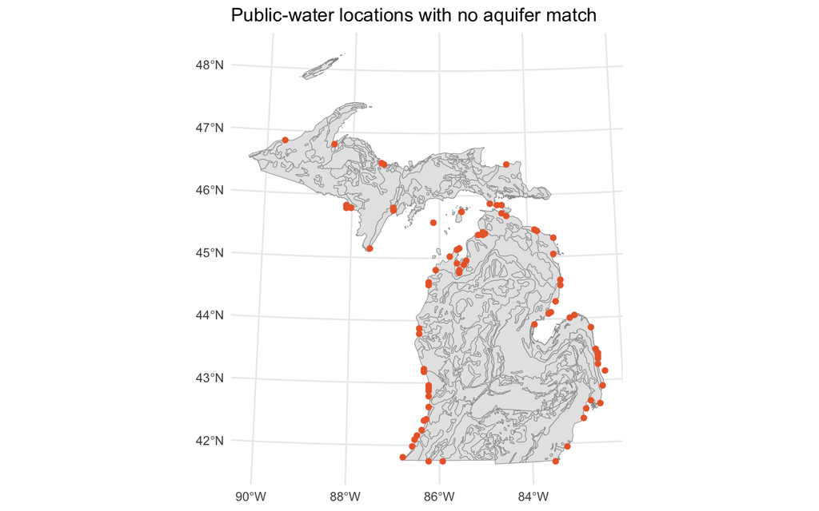

The gSSURGO geodatabase works in two steps: each sampling location is matched by point-in-polygon to a soil map unit (its `MUKEY`), and then `MUKEY` is used to join the soil attribute tables. Soil permeability is built first, on its own, so it can be inspected and mapped before any join happens.

Permeability here is the saturated hydraulic conductivity `ksat_r` (micrometers per second): how fast water, and anything dissolved in it, can move down through the soil. It is stored per soil horizon, so it has to be averaged up to the map unit.

```
Rows: 10,304
Columns: 4
$ mukey      <chr> "1249112", "1401604", "1412907", "1416080", "1455241", "145…
$ ksat_100cm <dbl> 2.2100000, 92.0000000, 21.7000008, 21.7000008, 89.5958515, …
$ perm_class <fct> Moderately high, High, High, High, High, High, High, High, …
$ perm_code  <int> 4, 5, 5, 5, 5, 5, 5, 5, 5, 5, 5, 5, 5, 5, 5, 5, 5, 5, 5, 3,…
```

```
# A tibble: 1 × 5
  n_mukeys_with_ksat min_ksat median_ksat mean_ksat max_ksat
               <int>    <dbl>       <dbl>     <dbl>    <dbl>
1              10304    0.019        20.9      34.5     282.
```

```
# A tibble: 1 × 3
  n_mukeys_total n_mukeys_no_ksat pct_no_ksat
           <int>            <int>       <dbl>
1          10664              360         3.4
```

```
# A tibble: 5 × 3
  perm_class      n_mukeys share
  <fct>              <int> <dbl>
1 Low                   32 0.003
2 Moderately low       470 0.046
3 Moderately high     3119 0.303
4 High                6557 0.636
5 Very high            126 0.012
```

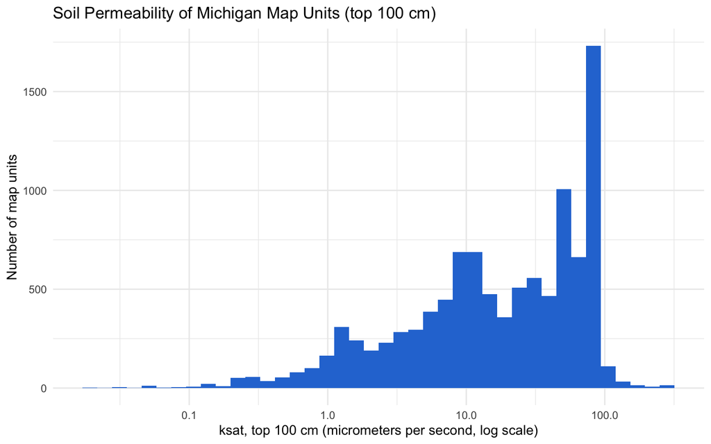

The classes follow the NRCS scale in micrometers per second: very low is under 0.01, low 0.01 to 0.1, moderately low 0.1 to 1, moderately high 1 to 10, high 10 to 100, and very high is 100 or more. The depth average uses a harmonic mean because water moves down through layers in series, so the tightest layer controls the flow, while components side by side are averaged by their percent. Map units with no usable `ksat_r` (for example open water or some urban land) have no row in `soil_perm` and will come out as missing after the join. Each value is an average over a map unit, so it describes the typical soil of that unit, not a single spot, and it covers only the top 100 cm, while wells often draw from deeper deposits.

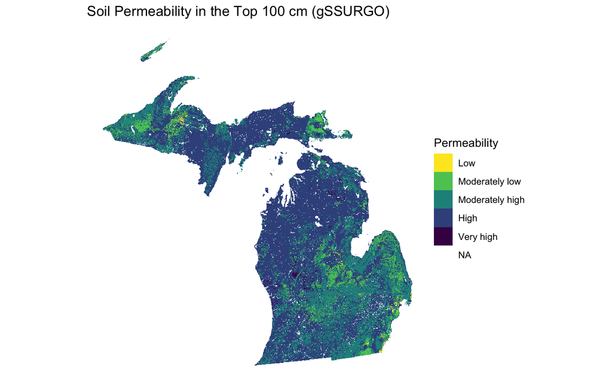

```
# A tibble: 1 × 3
  n_locations n_missing_soil pct_missing
        <int>          <int>       <dbl>
1        1610             76         4.7
```

```
Rows: 1,610
Columns: 12
$ hex_id       <dbl> 1, 2, 3, 4, 5, 6, 7, 8, 9, 10, 11, 12, 13, 14, 15, 16, 17…
$ MUKEY        <chr> "189870", "189781", "187493", "188867", "2507507", "18997…
$ drclassdcd   <chr> "Excessively drained", "Somewhat poorly drained", "Poorly…
$ hydgrpdcd    <chr> "A", "A/D", "B/D", NA, "A", NA, "A", "C/D", "C", "A", "C"…
$ wtdepannmin  <int> NA, 31, 0, NA, NA, NA, NA, 46, NA, NA, NA, NA, 0, NA, NA,…
$ brockdepmin  <int> NA, NA, NA, NA, NA, NA, NA, NA, NA, NA, NA, NA, NA, NA, N…
$ slopegradwta <dbl> 2.9, 1.0, 0.1, NA, 11.4, NA, 3.0, 3.6, 14.3, 9.0, 13.6, 9…
$ soc0_150     <dbl> 13007, 9967, 18601, NA, 11875, NA, 6160, 10510, 7643, 504…
$ aws0_150     <dbl> 107.90, 90.95, 196.25, NA, 99.08, NA, 159.12, 261.64, 227…
$ droughty     <int> 1, 1, 0, NA, 1, NA, 0, 0, 1, 1, 0, 1, 1, NA, 0, 1, 0, 0, …
$ ksat_100cm   <dbl> 57.1955928, 61.6761457, 5.1568698, NA, 58.6400000, NA, 15…
$ perm_class   <fct> High, High, Moderately high, NA, High, NA, High, Moderate…
```

```
# A tibble: 1 × 9
  drclassdcd hydgrpdcd wtdepannmin brockdepmin slopegradwta soc0_150 aws0_150
       <dbl>     <dbl>       <dbl>       <dbl>        <dbl>    <dbl>    <dbl>
1       11.2      11.1        54.5        98.7          9.5     10.1     10.1
# ℹ 2 more variables: droughty <dbl>, ksat_100cm <dbl>
```

**Procedure**

1. Follow the locations through the join stage by stage: inside a soil polygon, then a map unit record, then a permeability value.
2. Separate the two reasons a location can end up without permeability.
3. Check how many locations share a map unit.

**Key points**

- A location is lost either because it sits outside every soil polygon (open water, shoreline) or because its map unit has no usable `ksat_r` (urban land, pits).
- Locations that share a map unit get an identical soil value, so soil is a coarser measure than the number of locations suggests.

```
# A tibble: 4 × 3
  stage                n_locations pct_of_all
  <chr>                      <int>      <dbl>
1 n_all_locations             1610      100
2 n_in_soil_polygon           1534       95.3
3 n_with_map_unit_data        1457       90.5
4 n_with_permeability         1452       90.2
```

```
# A tibble: 3 × 3
  permeability_status                      n_locations   pct
  <chr>                                          <int> <dbl>
1 Has permeability                                1452  90.2
2 In a soil polygon, no permeability value          82   5.1
3 Outside soil polygons                             76   4.7
```

```
# A tibble: 10 × 2
   muname                   n_locations
   <chr>                          <int>
 1 Water                             66
 2 Urban land                         5
 3 Fresh water marsh                  2
 4 Aquents, sandy and loamy           1
 5 Dune land                          1
 6 Gravel pits                        1
 7 Lake beaches                       1
 8 Pits                               1
 9 Pits and Dumps, mine               1
10 Pits, gravel                       1
```

```
# A tibble: 1 × 4
  n_distinct_map_units median_locations_per_mu max_locations_per_mu
                 <int>                   <dbl>                <int>
1                 1096                       1                   12
# ℹ 1 more variable: n_map_units_shared <int>
```

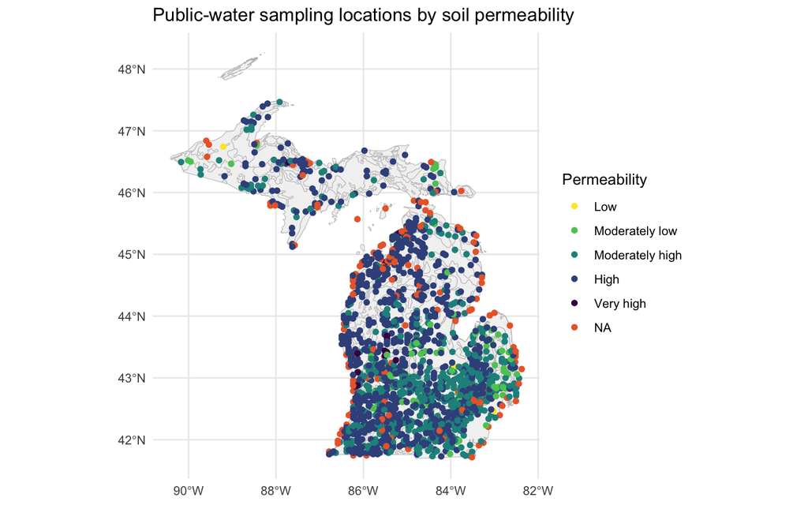

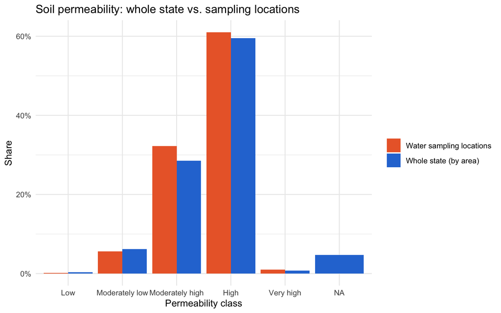

This compares the whole state, using every soil polygon through the 1 km grid, with where the water systems are sampled. Similar bars mean the sampling locations cover Michigan’s soils evenly. Differences are expected to some degree, because water systems cluster in towns while large forested areas have few, so a gap does not by itself mean a bias.

The soil columns kept for now are permeability (`ksat_100cm` and its class), drainage class (`drclassdcd`), hydrologic group (`hydgrpdcd`), minimum annual water table depth (`wtdepannmin`), depth to bedrock (`brockdepmin`), slope (`slopegradwta`), organic carbon to 150 cm (`soc0_150`), available water storage to 150 cm (`aws0_150`) and a droughty flag (`droughty`). A missing `wtdepannmin` commonly means no water table was recorded in the soil profile, so it is not always plain missing data.

```
Rows: 45,080
Columns: 44
$ geoid                      <dbl> 26129, 26129, 26129, 26129, 26129, 26129, 2…
$ longitude                  <dbl> -84.09276, -84.09276, -84.09276, -84.09276,…
$ latitude                   <dbl> 44.18548, 44.18548, 44.18548, 44.18548, 44.…
$ object_id                  <dbl> 1090, 1090, 1090, 1090, 1090, 1090, 1090, 1…
$ hex_id                     <dbl> 1, 1, 1, 1, 1, 1, 1, 1, 1, 1, 1, 1, 1, 1, 1…
$ system_name                <chr> "Cole Canoe Base", "Cole Canoe Base", "Cole…
$ wssn                       <dbl> 2004765, 2004765, 2004765, 2004765, 2004765…
$ system_type                <chr> "Non-Community Water Supply (Children's Cam…
$ loc_name                   <chr> "LOC03", "LOC03", "LOC03", "LOC03", "LOC03"…
$ sys_loc_code               <chr> "CHLCMP-038-LOC03", "CHLCMP-038-LOC03", "CH…
$ position_source            <chr> "EGLE", "EGLE", "EGLE", "EGLE", "EGLE", "EG…
$ phase_code                 <chr> "PHASE_2", "PHASE_2", "PHASE_2", "PHASE_2",…
$ task_code                  <chr> "PHASE_2", "PHASE_2", "PHASE_2", "PHASE_2",…
```

[output cut: 31 more lines]

Reencoding the Aquifer Characteristics

```
# A tibble: 9 × 2
  AQU_UNIT AQU_CHAR
  <chr>    <chr>
1 1        I - Thin drift (0-30 feet) overlying bedrock
2 2        II - Drift generally not an aquifer, may include thin interbeded aqu…
3 3a       IIIa - Drift usually unconfined at or near surface, generally consis…
4 3aX      IIIa - Drift usually unconfined at or near surface, generally consis…
5 3b       IIIb - Drift may or may not be aquifer at or near the surface. Drift…
6 3bX      IIIb - Drift may or may not be aquifer at or near the surface. Drift…
7 3bX      IIIb - Drift may or may not be aquifer at or near the surface. Drift…
8 4        IV - Drift may be an unconfined aquifer to bedrock. Not possible to …
9 <NA>     <NA>
```

```
# A tibble: 6 × 2
  aquifer_label                              n_locations
  <fct>                                            <int>
1 IIIB: Interbedded, variable near surface           802
2 IIIA: Interbedded, unconfined near surface         441
3 II: Drift generally not an aquifer                 210
4 <NA>                                                77
5 I: Thin drift over bedrock                          52
6 IV: Possible aquifer, undelineated                  28
```

```
# A tibble: 5 × 2
  aquifer_label                              n_sites
  <chr>                                        <int>
1 I: Thin drift over bedrock                       8
2 II: Drift generally not an aquifer              78
3 IIIA: Interbedded, unconfined near surface      96
4 IIIB: Interbedded, variable near surface       109
5 IV: Possible aquifer, undelineated               9
```

Everything in this section works at the **hex_id which is the sampling location** for location-level modeling, before the system level analysis of the exact public water drinking sites are analysed

```
# A tibble: 0 × 2
# ℹ 2 variables: hex_id <dbl>, n_rows_per_hex <int>
```

```
[1] 1610
```

This chunk collapses modeling_data from 45,080 analyte-level rows down to 1,610 rows — one per sampling location by keeping only the columns that don’t vary by analyte (Hazard_Index, aquifer, soil, distance, etc.) and dropping the duplicate rows that resulted from testing 28 different chemicals at each location.No hex_id ended up with more than one row and the final count is 1,610 rows.

```
# A tibble: 1 × 3
  n_hex_ids n_water_systems n_system_types
      <int>           <int>          <int>
1      1610            1528             12
```

There are water locations that have more than one sampling location that is why the hex-ids dont match the sytem name

```
# A tibble: 0 × 2
# ℹ 2 variables: hex_id <dbl>, n_system_names <int>
```

```
# A tibble: 0 × 2
# ℹ 2 variables: system_name <chr>, n_system_types <int>
```

Confirms that every system name or water sytem has one sytem type

```
# A tibble: 1 × 3
  min_locations median_locations max_locations
          <int>            <dbl>         <int>
1             1                1             9
```

Most water syetms have 1 sampling location however there are some that have upto 9 locations that is why we shrink it to the highest

```
# A tibble: 1 × 2
  n_locations_missing_system pct_missing_system
                       <int>              <dbl>
1                          9                0.6
```

These locations are grouped together as a single “system” in the system-level tables, which would make that row look like a large multi-location system. They are left as they are here so the results stay comparable; if the count above is not zero, decide whether to drop them or assign them real system names before drawing conclusions about individual systems.

```
# A tibble: 1 × 3
  n_locations n_missing_aquifer pct_missing
        <int>             <int>       <dbl>
1        1610                77         4.8
```

```
# A tibble: 6 × 2
  aquifer_label                              n_locations
  <fct>                                            <int>
1 I: Thin drift over bedrock                          52
2 II: Drift generally not an aquifer                 210
3 IIIA: Interbedded, unconfined near surface         441
4 IIIB: Interbedded, variable near surface           802
5 IV: Possible aquifer, undelineated                  28
6 <NA>                                                77
```

```
# A tibble: 5 × 7
  aquifer_label        pct_detected mean_hazard p90_hazard max_value n_locations
  <fct>                       <dbl>       <dbl>      <dbl>     <dbl>       <int>
1 I: Thin drift over …          3.8        0.09      0          4.5           52
2 II: Drift generally…          9          0.21      0         34.7          210
3 IIIA: Interbedded, …         22.4        0.14      0.211     10            441
4 IIIB: Interbedded, …         11.6        0.07      0.001      9.3          802
5 IV: Possible aquife…          7.1        0.04      0          0.91          28
# ℹ 1 more variable: water_systems <int>
```

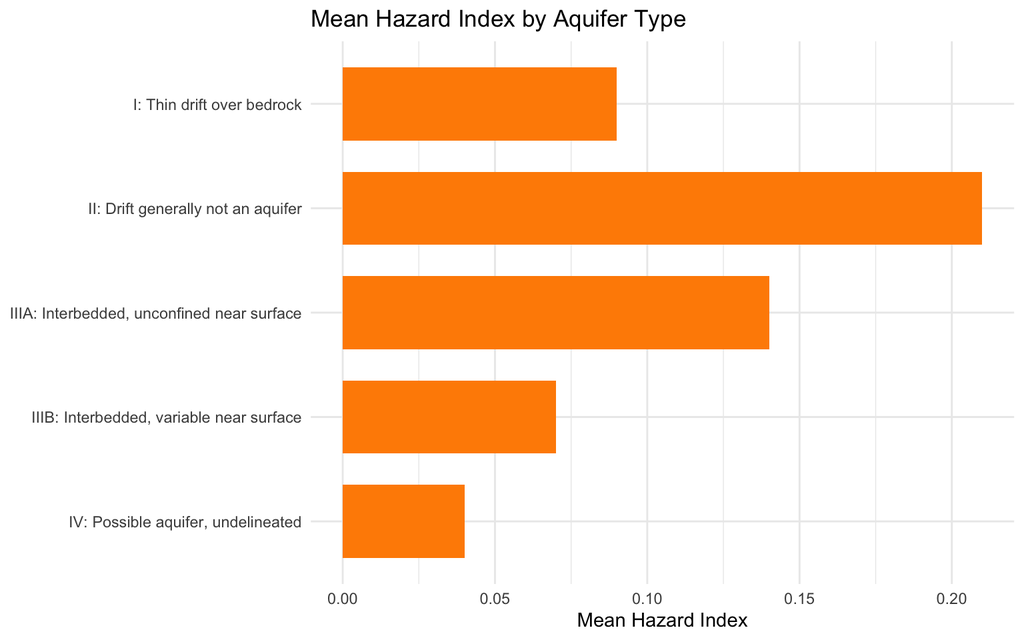

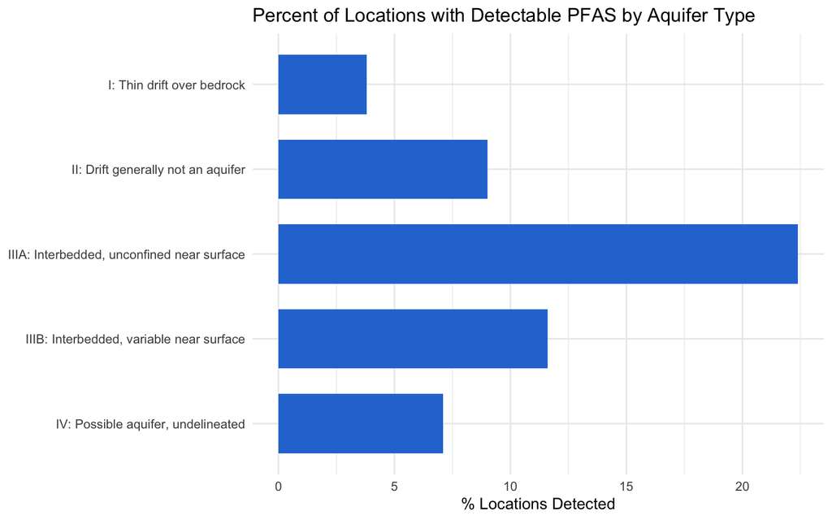

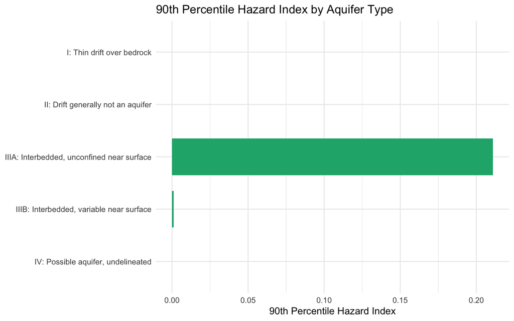

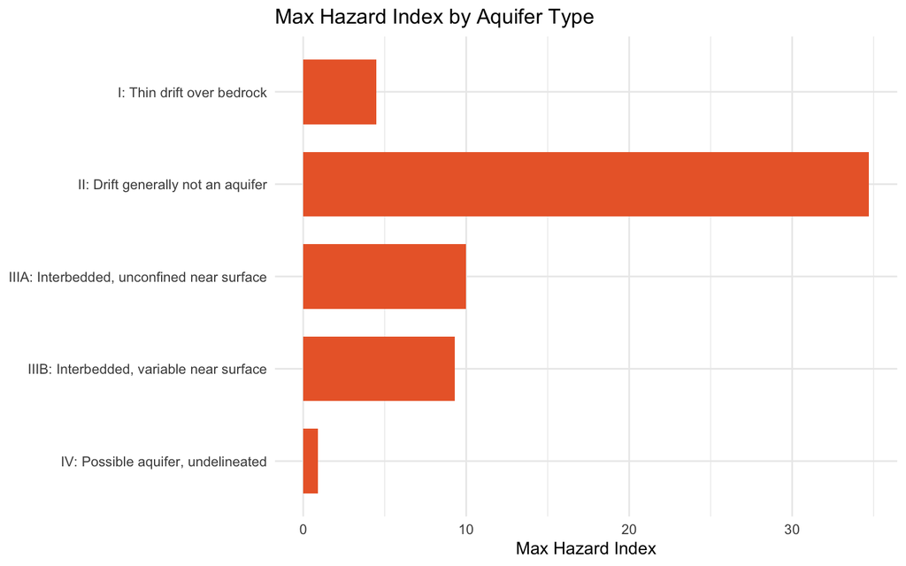

mean and pct_detected tell you how widespread contamination is within each aquifer type, while p90 and max tell you how severe it gets at the tail. Reading them together: an aquifer type with low pct_detected but a high max_value means it’s mostly clean with one bad outlier; high pct_detected and high p90 together means contamination is broadly present, not just a fluke.

```
# A tibble: 12 × 5
   system_short mean_hazard median_hazard n_locations water_systems
   <chr>              <dbl>         <dbl>       <int>         <int>
 1 OFFICE              0.28             0           5             5
 2 MUN                 0.15             0         985           913
 3 SCH                 0.1              0         234           234
 4 DAYCARE             0.04             0          80            80
 5 CHLCMP              0.02             0         110           105
 6 INDUS               0.02             0         116           111
 7 MEDCAR              0.01             0          55            55
 8 ADFSTC              0                0           6             6
 9 MOTEL               0                0           4             4
10 PARK                0                0           2             2
11 RESD                0                0           1             1
12 TRB                 0                0          12            12
```

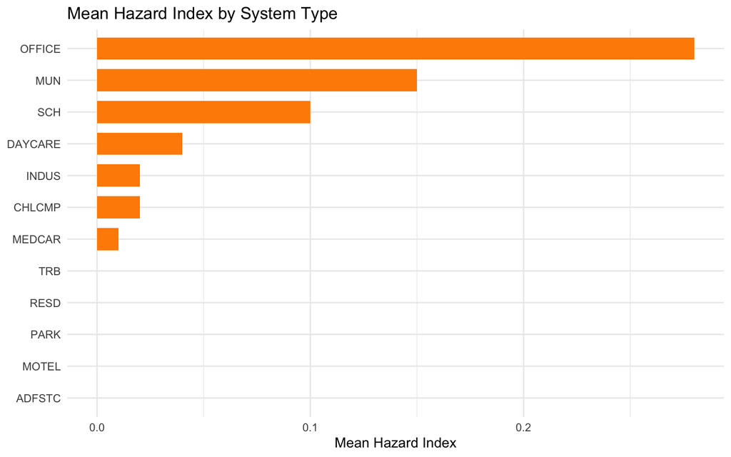

```
# A tibble: 1 × 4
  min_dist_m median_dist_m mean_dist_m max_dist_m
       <dbl>         <dbl>       <dbl>      <dbl>
1        260         10471       14201      79144
```

```
# A tibble: 2 × 3
  pfas_site_nearby n_locations   pct
  <lgl>                  <int> <dbl>
1 FALSE                   1261  78.3
2 TRUE                     349  21.7
```

```
# A tibble: 14 × 2
   nearest_site_type      n_locations
   <chr>                        <int>
 1 Landfill                       699
 2 Industrial                     229
 3 Wastewater                     135
 4 Airport                        120
 5 Plating                        116
 6 Military                        94
 7 Fire Related                    83
 8 Laundromat/Dry Cleaner          64
 9 Paper Manufacturing             20
10 Unknown                         18
11 Tannery                         15
12 Laundromat/DryCleaner            9
13 Refinery                         7
14 Fire Station                     1
```

```
# A tibble: 2 × 5
  pfas_site_nearby mean_hazard median_hazard n_locations water_systems
  <lgl>                  <dbl>         <dbl>       <int>         <int>
1 FALSE                 0.0681             0        1261          1212
2 TRUE                  0.261              0         349           330
```

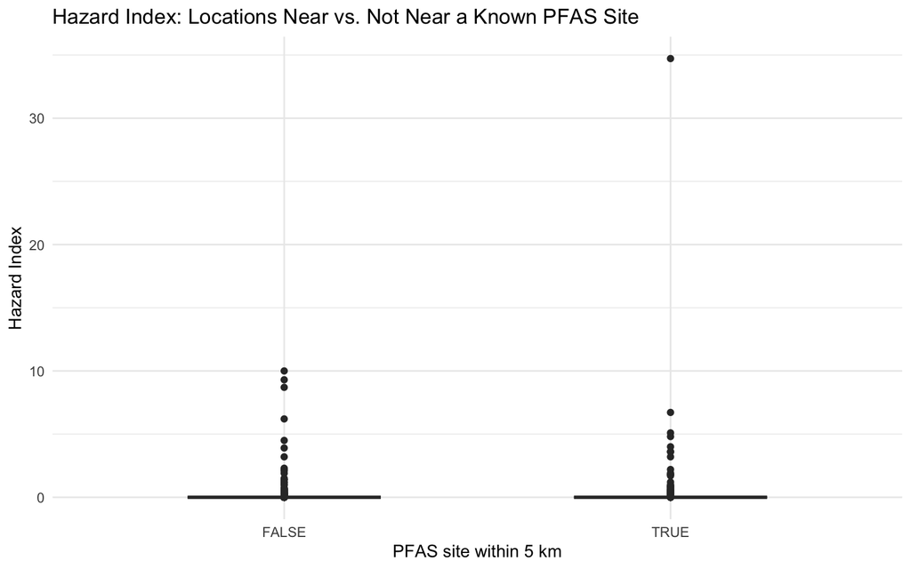

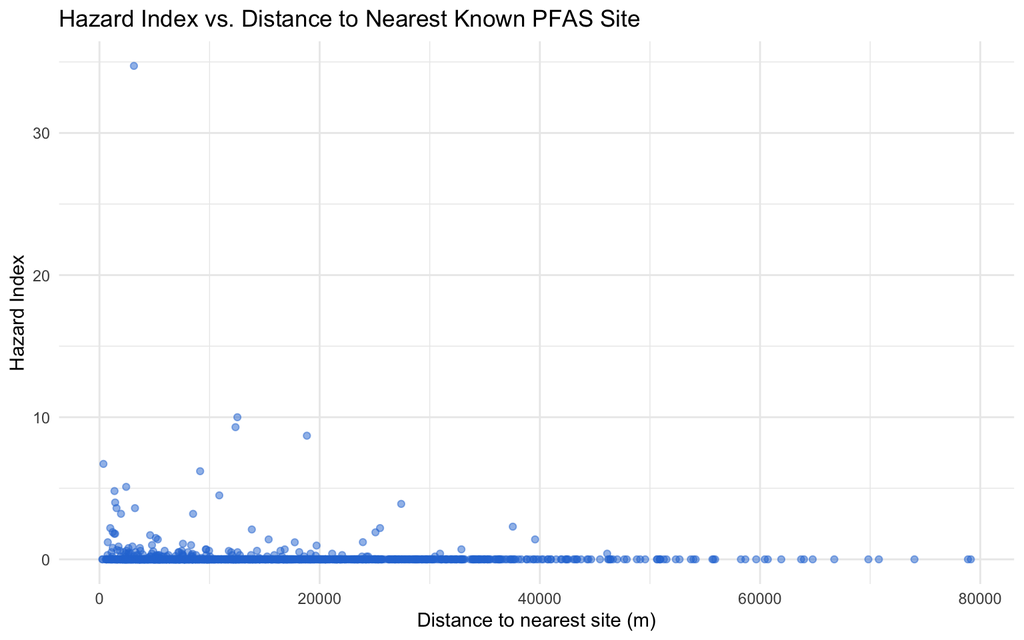

```
# A tibble: 5 × 3
  aquifer_label                              `FALSE` `TRUE`
  <fct>                                        <int>  <int>
1 I: Thin drift over bedrock                      48      4
2 II: Drift generally not an aquifer             170     40
3 IIIA: Interbedded, unconfined near surface     321    120
4 IIIB: Interbedded, variable near surface       635    167
5 IV: Possible aquifer, undelineated              23      5
```

```
# A tibble: 5 × 3
  aquifer_label                              `FALSE` `TRUE`
  <fct>                                        <int>  <int>
1 I: Thin drift over bedrock                      46      4
2 II: Drift generally not an aquifer             166     36
3 IIIA: Interbedded, unconfined near surface     316    115
4 IIIB: Interbedded, variable near surface       615    163
5 IV: Possible aquifer, undelineated              23      5
```

**Procedure**

1. Check whether missing permeability clusters in particular system types or aquifers, and whether those locations look different on hazard.
2. Compare the Hazard Index across permeability classes, the same way it was compared across aquifer types.
3. Check how permeability overlaps with aquifer type and distance before it goes into the models.

**Key points**

- Models drop systems with no permeability, so it matters whether those systems are a random slice or a distinct group.
- Aquifer type and permeability describe related things (the geology and the soil above it), so some overlap is expected.
- This is exploration only; the models later decide whether permeability adds anything beyond distance and aquifer.

```
# A tibble: 12 × 4
   system_short n_locations n_missing_ksat pct_missing_ksat
   <chr>              <int>          <int>            <dbl>
 1 TRB                   12              3             25
 2 ADFSTC                 6              1             16.7
 3 MUN                  985            119             12.1
 4 CHLCMP               110             13             11.8
 5 INDUS                116              7              6
 6 MEDCAR                55              3              5.5
 7 DAYCARE               80              3              3.8
 8 SCH                  234              9              3.8
 9 MOTEL                  4              0              0
10 OFFICE                 5              0              0
11 PARK                   2              0              0
12 RESD                   1              0              0
```

```
# A tibble: 6 × 4
  aquifer_label                      n_locations n_missing_ksat pct_missing_ksat
  <fct>                                    <int>          <int>            <dbl>
1 I: Thin drift over bedrock                  52              5              9.6
2 II: Drift generally not an aquifer         210              9              4.3
3 IIIA: Interbedded, unconfined nea…         441             34              7.7
4 IIIB: Interbedded, variable near …         802             31              3.9
5 IV: Possible aquifer, undelineated          28              2              7.1
6 <NA>                                        77             77            100
```

```
# A tibble: 2 × 4
  soil_status            n_locations pct_detected mean_hazard
  <chr>                        <int>        <dbl>       <dbl>
1 Has permeability value        1452         13.5        0.1
2 No permeability value          158         17.1        0.19
```

```
# A tibble: 5 × 7
  perm_class      pct_detected mean_hazard p90_hazard max_value n_locations
  <fct>                  <dbl>       <dbl>      <dbl>     <dbl>       <int>
1 Low                      0          0         0           0             3
2 Moderately low           7.4        0.06      0           1.7          81
3 Moderately high          8.5        0.03      0           6.2         468
4 High                    16.7        0.15      0.006      34.7         886
5 Very high               14.3        0.04      0.162       0.3          14
# ℹ 1 more variable: water_systems <int>
```

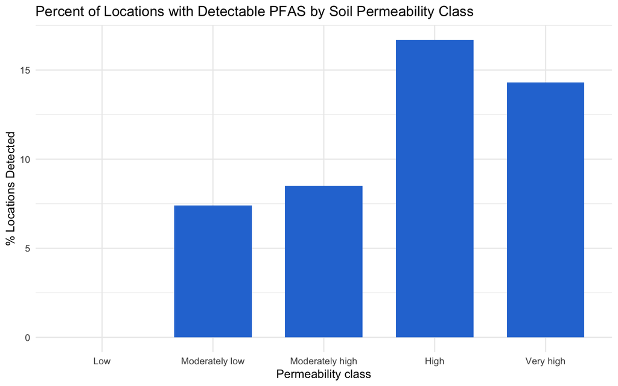

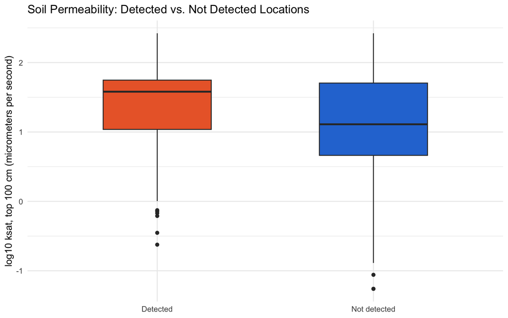

```
# A tibble: 5 × 6
  aquifer_label       `Moderately low` `Moderately high`  High `Very high`   Low
  <fct>                          <int>             <int> <int>       <int> <int>
1 I: Thin drift over…                1                13    32           1     0
2 II: Drift generall…               33                68    95           2     3
3 IIIA: Interbedded,…                6                71   321           9     0
4 IIIB: Interbedded,…               41               313   415           2     0
5 IV: Possible aquif…                0                 3    23           0     0
```

```
# A tibble: 1 × 3
  n_locations spearman_ksat_dist spearman_ksat_hazard
        <int>              <dbl>                <dbl>
1        1452              0.037                0.141
```

Read the tables together: a flat detection rate across permeability classes means permeability alone does not separate contaminated from clean locations, while a rising rate toward the permeable classes would match the idea that PFAS moves down faster through coarse soil. A correlation with distance close to zero means permeability brings information that distance does not already carry.

Distance only makes sense for the **known PFAS sites**, because it measures how far a location is from a source. Aquifer and soil are different: they describe the **ground** the water comes from, so here each aquifer type and each soil type is compared with risk directly, with no distance in the picture.

**Procedure**

1. Keep locations with an aquifer type and, for the soil questions, a soil value.
2. For each aquifer type, permeability class, drainage class and hydrologic group, count locations and systems and measure the detection rate and the Hazard Index.
3. Express each group’s detection rate relative to the overall rate (a risk ratio: 1 is average, above 1 is riskier than average).
4. Test whether the groups really differ, then cross aquifer type with permeability.
5. Fit ground-only logistic models (no distance) to see how much aquifer and soil explain on their own.

**Key points**

- A risk ratio compares a group with the average location, so it shows which ground types stand out, not just which have the most samples.
- Small groups give unstable rates, so read `n_locations` next to every percentage.
- Aquifer and soil belong to the **exact sampling location** (`hex_id`): each is the type of the polygon that location sits in, so the location is the natural unit for comparing ground types.
- A water system can have several `hex_id`s (1 to 9), and those can sit on different ground types, so a system can appear in more than one group. Counts of systems therefore do not add up across groups, and `n_water_systems` below counts a system once per group it appears in.
- Locations in the same system are not independent, so a model with a system effect is shown next to the plain one, and a system-level view uses only systems that sit on a single type.

```
# A tibble: 1 × 6
  n_systems n_multi_location_syst…¹ n_span_2plus_aquifers n_span_2plus_perm_cl…²
      <int>                   <int>                 <int>                  <int>
1      1466                      52                    16                     17
# ℹ abbreviated names: ¹n_multi_location_systems, ²n_span_2plus_perm_classes
# ℹ 2 more variables: pct_of_multi_span_aquifers <dbl>,
#   pct_of_multi_span_perm <dbl>
```

Because ground type is a property of the exact location, a system with several `hex_id`s is not one ground type by default. The counts above show how many systems straddle types. Where that number is small, assigning one type per system (the highest-Hazard-Index location, as the system-level models do) loses little; where it is large, the location-level tables below are the more faithful view, and the system-level view further down keeps only systems that sit on a single type.

```
# A tibble: 5 × 5
  aquifer_label          n_water_systems n_systems_detected pct_systems_detected
  <fct>                            <int>              <int>                <dbl>
1 I: Thin drift over be…              48                  2                  4.2
2 II: Drift generally n…             200                 18                  9
3 IIIA: Interbedded, un…             418                 97                 23.2
4 IIIB: Interbedded, va…             758                 90                 11.9
5 IV: Possible aquifer,…              26                  1                  3.8
# ℹ 1 more variable: mean_locations_per_system <dbl>
```

```
# A tibble: 5 × 5
  perm_class      n_water_systems n_systems_detected pct_systems_detected
  <fct>                     <int>              <int>                <dbl>
1 Low                           2                  0                  0
2 Moderately low               73                  5                  6.8
3 Moderately high             439                 37                  8.4
4 High                        849                145                 17.1
5 Very high                    13                  2                 15.4
# ℹ 1 more variable: mean_locations_per_system <dbl>
```

Compare these system rates with the location rates in the next tables. If they tell the same story, the finding does not depend on the difference between 1,610 `hex_id`s and about 1,500 systems.

```
# A tibble: 5 × 9
  aquifer_label        n_locations n_water_systems n_detected n_systems_detected
  <fct>                      <int>           <int>      <int>              <int>
1 I: Thin drift over …          52              50          2                  2
2 II: Drift generally…         210             202         19                 19
3 IIIA: Interbedded, …         441             430         99                 99
4 IIIB: Interbedded, …         802             774         93                 91
5 IV: Possible aquife…          28              28          2                  2
# ℹ 4 more variables: pct_detected <dbl>, risk_ratio <dbl>, mean_hazard <dbl>,
#   p90_hazard <dbl>
```

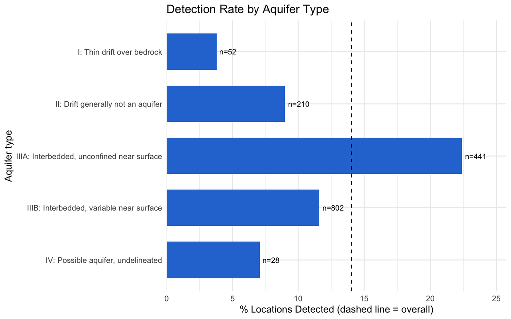

Three views of soil are compared: how fast water moves through it (permeability class), how well it drains (drainage class) and its runoff group (hydrologic group, A drains fastest and D slowest).

```
# A tibble: 5 × 9
  perm_class      n_locations n_water_systems n_detected n_systems_detected
  <fct>                 <int>           <int>      <int>              <int>
1 Low                       3               3          0                  0
2 Moderately low           81              79          6                  6
3 Moderately high         468             453         40                 39
4 High                    886             863        148                148
5 Very high                14              14          2                  2
# ℹ 4 more variables: pct_detected <dbl>, risk_ratio <dbl>, mean_hazard <dbl>,
#   p90_hazard <dbl>
```

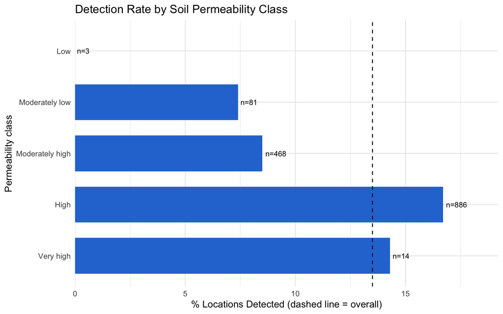

```
# A tibble: 7 × 9
  drclassdcd           n_locations n_water_systems n_detected n_systems_detected
  <chr>                      <int>           <int>      <int>              <int>
1 Excessively drained          121             120         33                 33
2 Somewhat excessivel…         100              99         18                 18
3 Well drained                 516             506         75                 74
4 Moderately well dra…          99              98         11                 11
5 Very poorly drained          163             163         17                 17
6 Somewhat poorly dra…         266             265         26                 26
7 Poorly drained               164             160         10                 10
# ℹ 4 more variables: pct_detected <dbl>, risk_ratio <dbl>, mean_hazard <dbl>,
#   p90_hazard <dbl>
```

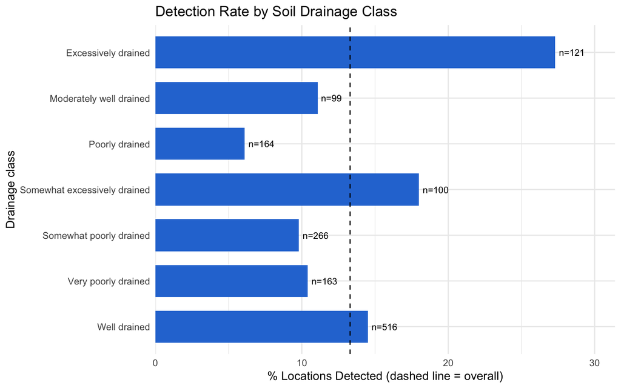

```
# A tibble: 7 × 9
  hydgrpdcd n_locations n_water_systems n_detected n_systems_detected
  <chr>           <int>           <int>      <int>              <int>
1 A                 468             459         93                 93
2 A/D               220             220         30                 30
3 B                 155             153         18                 18
4 B/D                94              94          8                  8
5 C                 139             139         21                 21
6 C/D               272             267         14                 14
7 D                  84              82          9                  9
# ℹ 4 more variables: pct_detected <dbl>, risk_ratio <dbl>, mean_hazard <dbl>,
#   p90_hazard <dbl>
```

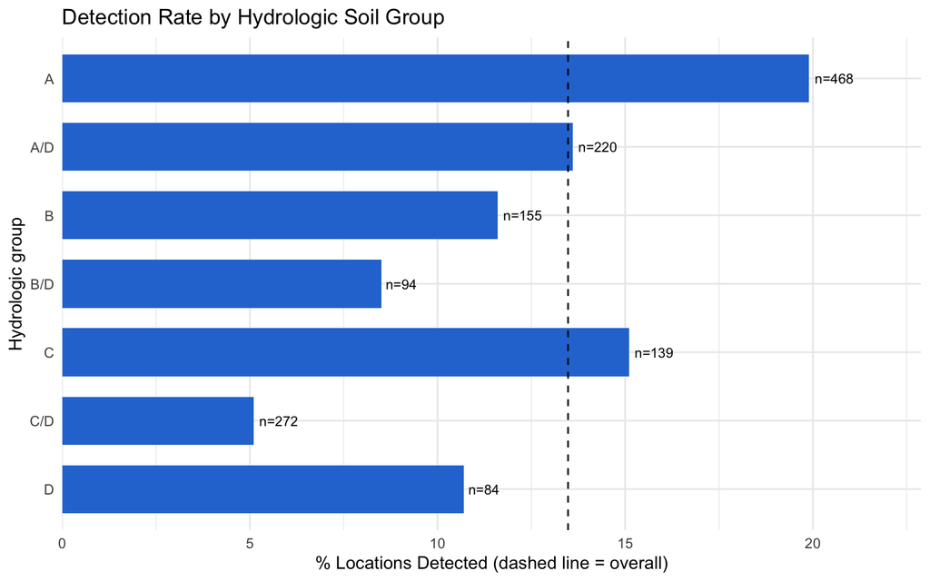

```
# A tibble: 4 × 5
  factor             n_groups n_locations p_detection_differs p_hazard_differs
  <chr>                 <int>       <int>               <dbl>            <dbl>
1 Aquifer type              5        1533              0.0002     0.0000000747
2 Permeability class        5        1452              0.0018     0.000354
3 Drainage class            7        1429              0.0002     0.00000642
4 Hydrologic group          7        1432              0.0002     0.0000037
```

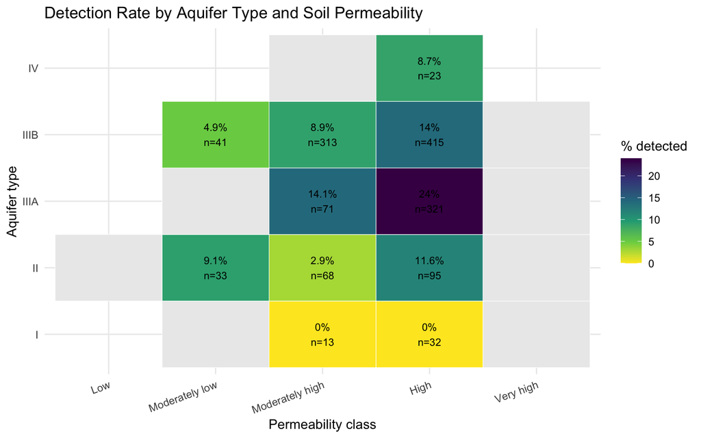

```
# A tibble: 3 × 5
  model                  n_locations   aic   bic mcfadden_r2
  <chr>                        <int> <dbl> <dbl>       <dbl>
1 Aquifer only                  1452 1113. 1140.       0.04
2 Permeability only             1452 1123. 1134.       0.026
3 Aquifer + permeability        1452 1097. 1128.       0.056
```

```
Analysis of Deviance Table

Model 1: detected_yes ~ log_ksat
Model 2: detected_yes ~ aquifer_short + log_ksat
  Resid. Df Resid. Dev Df Deviance  Pr(>Chi)
1      1450     1119.1
2      1446     1084.8  4   34.358 6.292e-07 ***
---
Signif. codes:  0 '***' 0.001 '**' 0.01 '*' 0.05 '.' 0.1 ' ' 1
```

```
Analysis of Deviance Table

Model 1: detected_yes ~ aquifer_short
Model 2: detected_yes ~ aquifer_short + log_ksat
  Resid. Df Resid. Dev Df Deviance  Pr(>Chi)
1      1447     1103.4
2      1446     1084.8  1   18.593 1.618e-05 ***
---
Signif. codes:  0 '***' 0.001 '**' 0.01 '*' 0.05 '.' 0.1 ' ' 1
```

```
# A tibble: 6 × 5
  term              estimate std.error statistic   p.value
  <chr>                <dbl>     <dbl>     <dbl>     <dbl>
1 log_ksat           1.81e+0     0.143    4.16   0.0000319
2 (Intercept)        2.96e-8   347.      -0.0500 0.960
3 aquifer_shortIIIA  4.07e+6   347.       0.0439 0.965
4 aquifer_shortIIIB  2.26e+6   347.       0.0422 0.966
5 aquifer_shortII    1.56e+6   347.       0.0412 0.967
6 aquifer_shortIV    1.10e+6   347.       0.0401 0.968
```

```
# A tibble: 6 × 5
  term           odds_ratio_plain p_plain odds_ratio_system_ef…¹ p_system_effect
  <chr>                     <dbl>   <dbl>                  <dbl>           <dbl>
1 (Intercept)             2.96e-8 9.6 e-1               4.46e-13           0.996
2 aquifer_short…          1.56e+6 9.67e-1               5.87e+ 6           0.998
3 aquifer_short…          4.07e+6 9.65e-1               2.07e+ 7           0.998
4 aquifer_short…          2.26e+6 9.66e-1               6.11e+ 6           0.998
5 aquifer_short…          1.10e+6 9.68e-1               2.84e+ 7           0.998
6 log_ksat                1.81e+0 3.19e-5               1.72e+ 0           0.406
# ℹ abbreviated name: ¹odds_ratio_system_effect
```

If the odds ratios barely move once each system gets its own intercept, the location-level result is not driven by systems that simply have more `hex_id`s. If they shrink or lose significance, treat the location tables as optimistic and lean on the system-level models.

Read the tables together. A risk ratio well above 1 with a decent `n_locations` marks a ground type that carries more detection than average, and a small p-value in the test table says the differences between groups are more than chance. The ground-only models then show how much aquifer and soil explain without any help from distance; a McFadden R-squared near zero would mean the ground type alone says little about where PFAS turns up, and any pattern is more likely driven by where the sources are.

Distance applies only to the **known PFAS sites** (the source). Aquifer and soil were compared with risk on their own, with no distance, in the section above; this section adds the source link and checks whether the ground changes it. The analysis follows the path PFAS would take to a drinking-water location: it starts at a **known PFAS site** (the source), moves down through the **soil** (infiltration), is carried by the **aquifer** (transport), and is measured at the **public water location** (the receptor). Each step below adds one layer to the previous one.

```
flowchart LR
  S["Known PFAS sites (source)<br/>distance to nearest site<br/>sites within 5 km"] --> SO["Soil permeability (infiltration)<br/>ksat, top 100 cm"]
  SO --> AQ["Aquifer type (transport)<br/>glacial drift class"]
  AQ --> W["Public water location (receptor)<br/>Hazard Index per hex_id"]
  W --> SY["Water system<br/>max Hazard Index"]
  SY --> M["Models<br/>baseline, Tweedie, hurdle"]
```

**Procedure**

1. Build one table of locations that have a distance, an aquifer and a permeability value, with distance bands and grouped permeability classes.
2. Step 1, source to receptor: detection rate by distance band.
3. Step 2, add the aquifer: detection rate by distance band within each aquifer type.
4. Step 3, add the soil: detection rate by distance band within each permeability group.
5. Step 4, all three together: aquifer and permeability combinations, split into near and far locations.
6. Map the pieces together and test whether permeability changes how much distance matters.

**Key points**

- Aquifer and soil permeability are measured **at the water location**, not at the PFAS site, so they describe the ground the water is drawn from, not the ground the contamination started in.
- Cells with fewer than 10 locations are left blank in the heatmaps, because their rates are not stable.
- This is a location-level exploration; locations in the same system share a system, so patterns here are a guide to what the system-level models should test.

```
# A tibble: 4 × 2
  distance_band n_locations
  <fct>               <int>
1 0-5 km                315
2 5-15 km               619
3 15-30 km              374
4 30+ km                144
```

```
# A tibble: 4 × 4
  distance_band n_locations pct_detected mean_hazard
  <fct>               <int>        <dbl>       <dbl>
1 0-5 km                315         21.6        0.26
2 5-15 km               619         13.2        0.08
3 15-30 km              374          9.4        0.03
4 30+ km                144          7.6        0.03
```

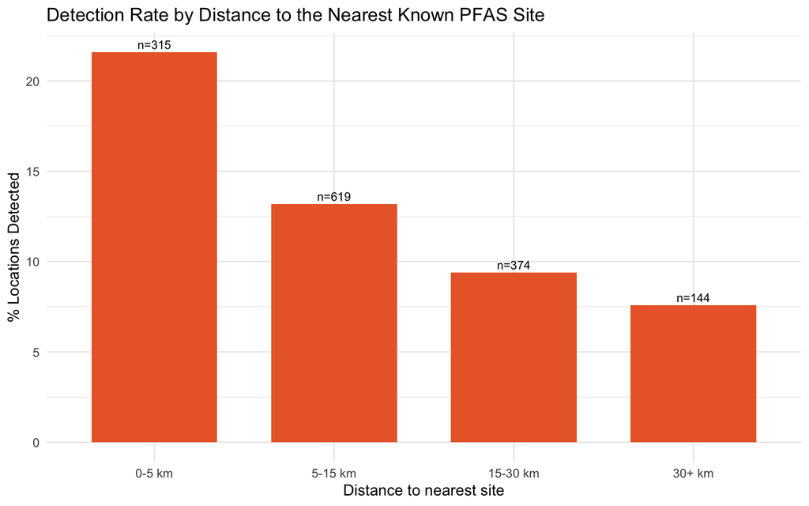

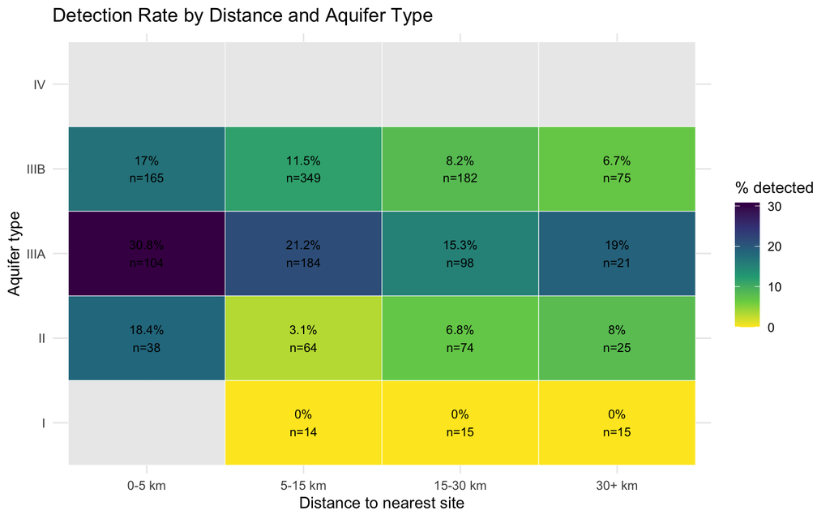

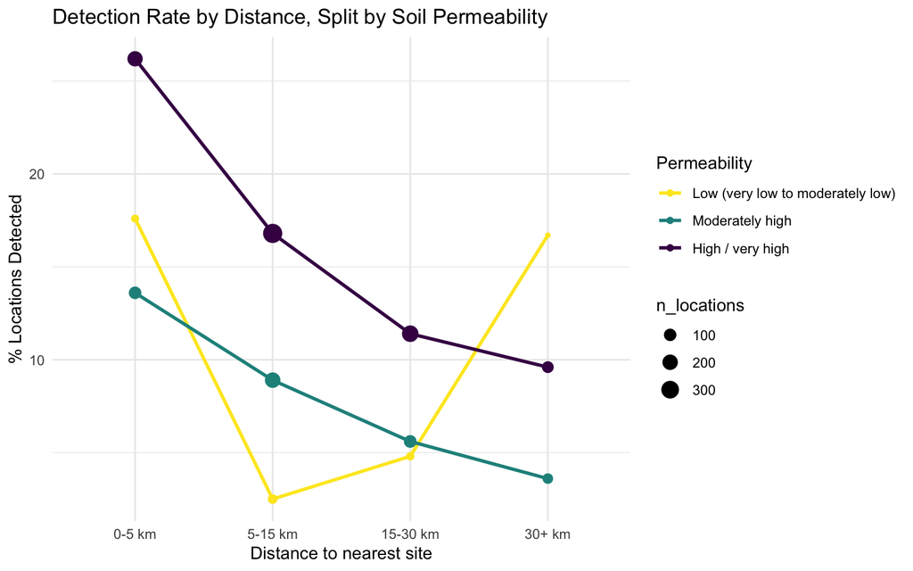

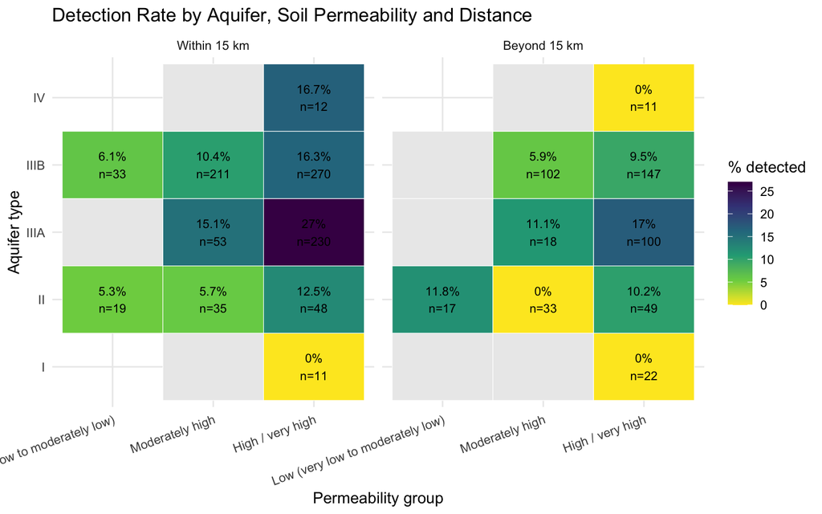

```
# A tibble: 10 × 5
   distance_group aquifer_short perm_group              n_locations pct_detected
   <fct>          <chr>         <fct>                         <int>        <dbl>
 1 Within 15 km   IIIA          High / very high                230         27
 2 Beyond 15 km   IIIA          High / very high                100         17
 3 Within 15 km   IIIB          High / very high                270         16.3
 4 Within 15 km   IIIA          Moderately high                  53         15.1
 5 Within 15 km   II            High / very high                 48         12.5
 6 Beyond 15 km   II            Low (very low to moder…          17         11.8
 7 Beyond 15 km   IIIA          Moderately high                  18         11.1
 8 Within 15 km   IIIB          Moderately high                 211         10.4
 9 Beyond 15 km   II            High / very high                 49         10.2
10 Beyond 15 km   IIIB          High / very high                147          9.5
```

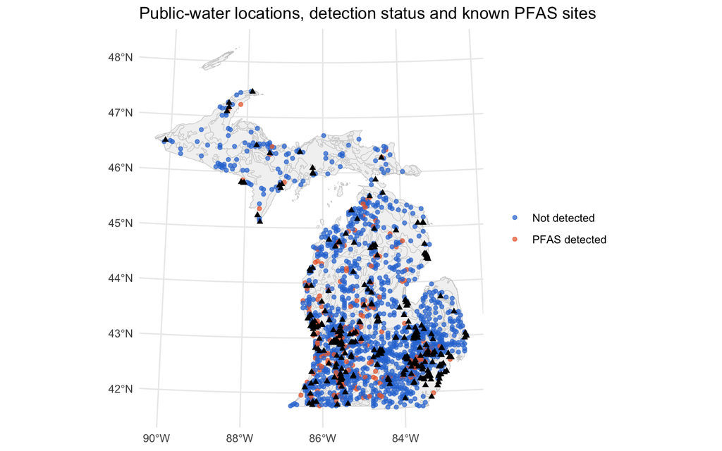

```
Analysis of Deviance Table

Model 1: detected_yes ~ log_distance + log_ksat
Model 2: detected_yes ~ log_distance * log_ksat
  Resid. Df Resid. Dev Df Deviance Pr(>Chi)
1      1449     1086.1
2      1448     1083.2  1   2.9157  0.08772 .
---
Signif. codes:  0 '***' 0.001 '**' 0.01 '*' 0.05 '.' 0.1 ' ' 1
```

```
# A tibble: 4 × 5
  term                  estimate std.error statistic p.value
  <chr>                    <dbl>     <dbl>     <dbl>   <dbl>
1 (Intercept)              0.218     1.98     -0.770  0.442
2 log_distance             0.877     0.218    -0.603  0.547
3 log_ksat                20.5       1.36      2.23   0.0261
4 log_distance:log_ksat    0.774     0.150    -1.71   0.0870
```

Read the steps in order. If the detection rate falls with distance in Step 1, the source-to-receptor link is visible. If that fall is steeper in some aquifer types (Step 2) or in permeable soils (Step 3), those layers modify the distance effect, and Step 4 shows which combinations carry the highest rates. The interaction test then checks whether permeability changes the distance slope. Locations in the same system are not independent, so treat these p-values as a guide, and rely on the system-level models for the formal comparison.

The location-level work above decides what goes into the system-level models:

- **Distance** applies only to the known PFAS sites; it is the source-to-receptor link tested in Step 1 and enters every model as `log(1 + distance)`.
- **Aquifer type** was compared with risk on its own (no distance) and then against the distance link (Step 2); it enters as a whole categorical variable.
- **Soil type** (permeability, drainage, hydrologic group) was compared with risk on its own (no distance); permeability was then tested with distance (Step 3 and the interaction test). All of these soil variables enter the models at the system’s highest-Hazard-Index location, and the selection decides which ones stay.
- **Missing soil or aquifer values** (join audit and the missingness tables) decide which systems are dropped, so every candidate model is fit on the same rows.

Next the locations are rolled up to one row per water system, because the public-health question is about systems.

```
[1] 1528
```

```
# A tibble: 1,528 × 7
   system_name         system_type n_hex_ids max_hazard mean_hazard hazard_range
   <chr>               <chr>           <int>      <dbl>       <dbl>        <dbl>
 1 LITTLE TRAVERSE BA… Community …         1      34.7        34.7             0
 2 WOODLAND SCHOOL     Community …         1      10          10               0
 3 ONEKAMA HIGH SCHOOL Community …         1       9.3         9.3             0
 4 FIFE LAKE ELEMENTA… Community …         1       8.7         8.7             0
 5 Robinson Elementar… School              1       6.72        6.72            0
 6 ALTO ELEMENTARY SC… Community …         1       6.2         6.2             0
 7 Central Montcalm S… School              1       5.1         5.1             0
 8 Parchment           Community …         1       4.81        4.81            0
 9 TILDEN MINING COMP… Community …         1       4.5         4.5             0
10 Kinross Township    Community …         1       4           4               0
# ℹ 1,518 more rows
# ℹ 1 more variable: min_distance_to_site_m <dbl>
```

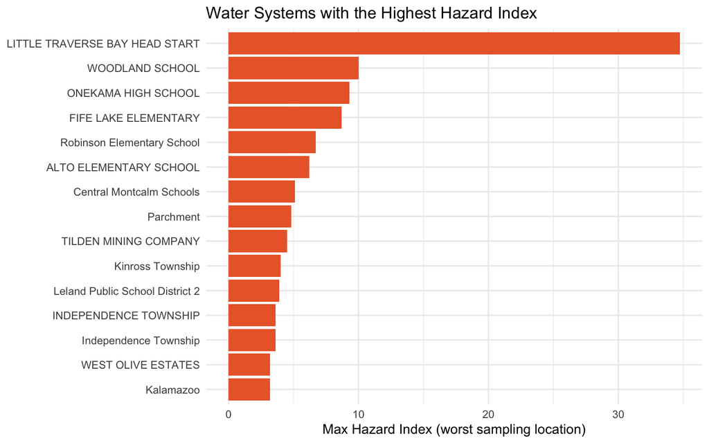

```
# A tibble: 1 × 3
  n_water_systems n_systems_above_alert pct_above_alert
            <int>                 <int>           <dbl>
1            1528                    32             2.1
```

```
[1] 66
```

```
# A tibble: 66 × 5
   system_name                 n_hex_ids hazard_range hazard_sd max_spread_m
   <chr>                           <int>        <dbl>     <dbl>        <dbl>
 1 Independence Township               2         3.6       2.55        4828.
 2 Kalamazoo                           4         3.2       1.6        19312.
 3 Plainwell                           2         1.91      1.35        4828.
 4 Union Township                      2         1.7       1.2         4828.
 5 <NA>                                9         1.4       0.46      447396.
 6 KI Sawyer                           2         0.91      0.64        4828.
 7 Waterford Township                  3         0.4       0.23        4828.
 8 Frenchtown Township                 2         0.3       0.21        4828.
 9 Evart, City of                      3         0.02      0.01        4828.
10 Consumers Energy West Olive         2         0.01      0           4828.
# ℹ 56 more rows
```

The check above showed that some systems have sampling locations several kilometres apart. Ground type belongs to each exact location, so the farther apart a system’s locations are, the more likely they sit on different aquifer types or soil permeability classes.

```
# A tibble: 2 × 5
  straddles_aquifers n_systems median_spread_km median_hazard_range
  <lgl>                  <int>            <dbl>               <dbl>
1 FALSE                     49              4.8                   0
2 TRUE                      16              4.8                   0
# ℹ 1 more variable: mean_hazard_range <dbl>
```

```
# A tibble: 2 × 5
  straddles_perm n_systems median_spread_km median_hazard_range
  <lgl>              <int>            <dbl>               <dbl>
1 FALSE                 48              4.8                   0
2 TRUE                  17              4.8                   0
# ℹ 1 more variable: mean_hazard_range <dbl>
```

```
# A tibble: 1 × 4
  n_systems spearman_spread_aquifers spearman_spread_perm spearman_aquifers_ha…¹
      <int>                    <dbl>                <dbl>                  <dbl>
1        65                   -0.002                0.269                  0.176
# ℹ abbreviated name: ¹spearman_aquifers_hazardrange
```

A clear positive link between spread and the number of ground types touched means the system-level ground type is a blurrier measure for wide systems. A positive link between touching more aquifer types and a larger hazard range would support the idea that the ground under a system’s locations helps explain why its readings differ, and is another reason the system uses its worst location (`max_hazard`) as the outcome.

```
# A tibble: 1 × 4
  mean_hazard median_hazard mean_log_hazard median_log_hazard
        <dbl>         <dbl>           <dbl>             <dbl>
1        0.12             0            0.05                 0
```

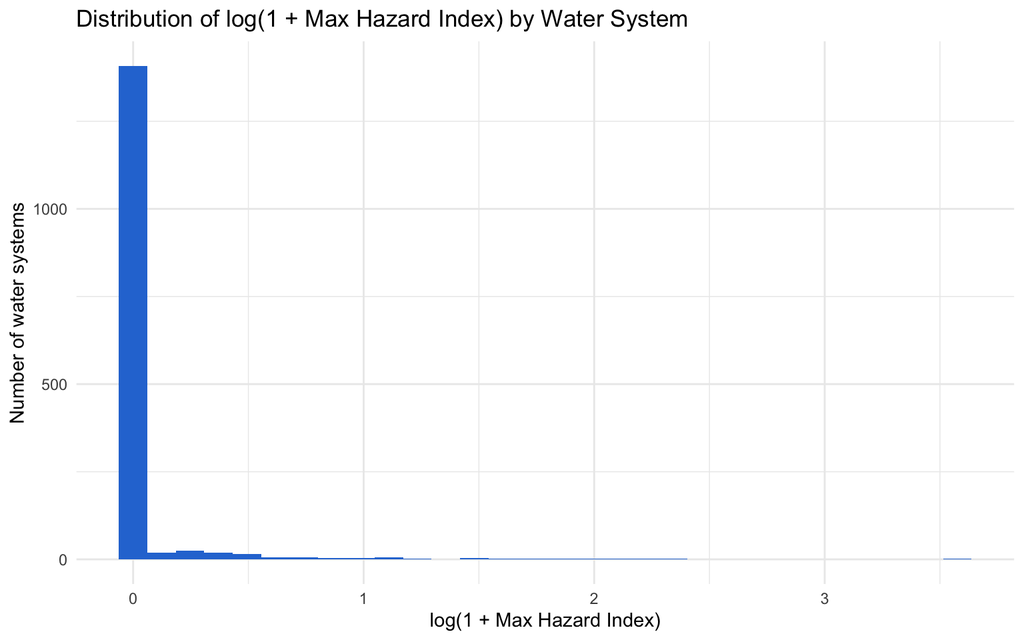

```
# A tibble: 1 × 4
  min_dist_m max_dist_m min_log_dist max_log_dist
       <dbl>      <dbl>        <dbl>        <dbl>
1        260      79144         5.56         11.3
```

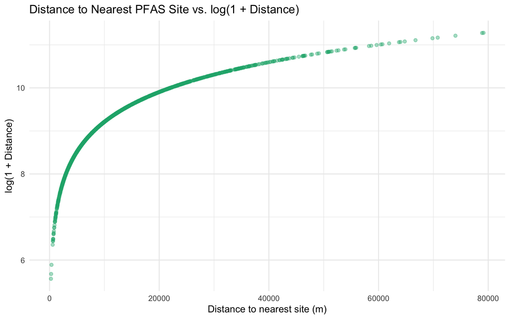

This is the **baseline model**: one regression line fit to every water system, with distance as the only predictor. The Tweedie and hurdle models further down are compared against it.

```
# A tibble: 2 × 5
  term                   estimate std.error statistic       p.value
  <chr>                     <dbl>     <dbl>     <dbl>         <dbl>
1 (Intercept)              0.369    0.0605       6.11 0.00000000127
2 min_distance_to_site_m  -0.0348   0.00654     -5.32 0.000000117
```

The log_hazard when log_distance = 0 is 0.369. So exponential of (0.369) - 1 is about 0.45 thus the baseline prediction for a system at distance zero is a Hazard Index around 0.45 even at zero distance, which means distance alone isn’t enough to push the typical prediction over the line.

The log distance estimate shows that being further away from a known site is connected to having a lower Hazard Index. There is 0.035% change in (1 + Hazard Index) per 1% increase in (1 + distance)

All these are significat to the model according to the p-values

```
# A tibble: 1 × 12
  r.squared adj.r.squared sigma statistic     p.value    df logLik   AIC   BIC
      <dbl>         <dbl> <dbl>     <dbl>       <dbl> <dbl>  <dbl> <dbl> <dbl>
1    0.0182        0.0176 0.234      28.3 0.000000117     1   55.2 -104. -88.3
# ℹ 3 more variables: deviance <dbl>, df.residual <int>, nobs <int>
```

The model only explains about 1.8% which then means that distance alone cannot be used as a measure of the influence of hazard index however this r squared value is significant according to the p-value which is significantly very low

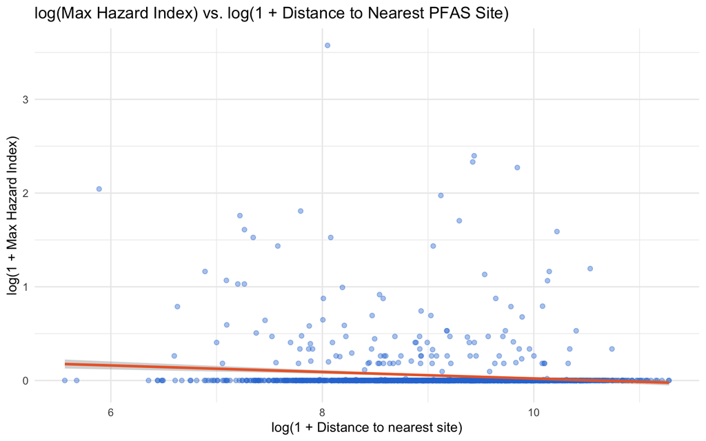

The Tweedie and hurdle models below use the same system-level table and the same automatic selection routine, so both are set up once here.

**Procedure**

1. Roll sampling locations up to one row per water system with every candidate predictor.
2. Keep systems with an aquifer match and add the transformed versions the models use.
3. Define one backward-elimination routine that works for any model and scores it by AIC or BIC.

**Key points**

- Every model starts from the same candidate variables (distance, nearby sites, aquifer, system type and all the soil variables), so results can be compared fairly.
- `n_hex_ids` is a control and is never dropped.
- `log_ksat` is soil permeability on a log10 scale at the system’s highest-Hazard-Index sampling location; for logistic and Tweedie parts an effect is per 10-fold increase in permeability.
- Categorical variables (`aquifer_label`, `system_group`, `drainage_class`, `hydro_group`, `droughty_flag`) are kept or dropped as a whole, not category by category.
- The AIC/BIC choice is automatic: BIC is used when there are fewer than 20 detected systems per candidate variable, otherwise AIC (see `SELECTION_MODE` below).

A system with several sampling locations is represented by the location with its highest Hazard Index, the same location that sets `max_hazard`. That location’s own aquifer type, soil permeability, distance to the nearest known PFAS site (from `pfas_sites1`) and count of sites within 5 km are used for the system, so the outcome, the source link and the ground type all describe the same spot. Set `DISTANCE_BASIS <- "nearest_any_location"` to take distance and site count from the closest of the system’s locations instead. The two checks below show how often this choice matters.

```
# A tibble: 1 × 4
  n_multi_location_systems n_tied_at_zero n_positive_peak n_positive_peak_tied
                     <int>          <int>           <int>                <int>
1                       66             54              12                    0
```

```
# A tibble: 1 × 3
  n_systems n_other_locations_differ_aquifer n_other_locations_differ_perm
      <int>                            <int>                         <int>
1        12                                4                             4
```

```
# A tibble: 1 × 4
  n_multi_location_systems n_distance_differs median_difference_km
                     <int>              <int>                <dbl>
1                       66                  5                    0
# ℹ 1 more variable: max_difference_km <dbl>
```

```
# A tibble: 1 × 4
  n_multi_location_systems median_range_log10 max_range_log10
                     <int>              <dbl>           <dbl>
1                       46               0.38            3.06
# ℹ 1 more variable: n_systems_over_10fold <int>
```

```
# A tibble: 1 × 4
  n_systems n_no_aquifer n_no_permeability n_complete_for_models
      <int>        <int>             <int>                 <int>
1      1528           66               143                  1385
```

```
# A tibble: 1 × 3
  n_water_systems n_detected pct_detected
            <int>      <int>        <dbl>
1            1385        193         13.9
```

```
# A tibble: 1 × 9
  n_systems pct_water_table_missing pct_bedrock_missing pct_slope_missing
      <int>                   <dbl>               <dbl>             <dbl>
1      1385                      50                98.5                 0
# ℹ 5 more variables: pct_organic_carbon_missing <dbl>,
#   pct_water_storage_missing <dbl>, n_drainage_classes <int>,
#   n_hydro_groups <int>, n_droughty_classes <int>
```

The candidate predictors are:

- **log(1 + distance to the nearest site):** the original question; distance from the system’s highest-Hazard-Index location to the closest site in `pfas_sites1`. The baseline model above still uses the closest of a system’s locations.
- **max_sites_within_5km:** how many known sites are nearby, not just the closest one. It overlaps with distance, so watch for unstable standard errors if both look odd.
- **n_hex_ids:** the number of sampling locations in the system (explained below).
- **aquifer_label:** the aquifer type under the system’s highest-Hazard-Index sampling location.
- **log_ksat:** soil permeability (log10 ksat, top 100 cm) at the system’s highest-Hazard-Index location; one unit means soil 10 times more permeable.
- **drainage_class, hydro_group, droughty_flag:** soil drainage class, hydrologic group and droughty flag at that location (missing becomes “Unknown”, classes under 5% of systems are lumped into OTHER).
- **water_table_depth, bedrock_depth:** minimum annual water table depth and depth to bedrock, each with a `_missing` indicator because a missing value usually means none was recorded.
- **slope, organic_carbon, water_storage:** slope, organic carbon to 150 cm and available water storage to 150 cm.
- The numeric soil terms are filled with the median where missing and standardised, so their coefficients are per one standard deviation, not per original unit.
- **system_short:** the system type, with rare types lumped into “other”.

Systems with no aquifer match (shoreline locations) or no soil permeability (open water, urban land) are dropped here, so these models use fewer systems than the baseline. A system’s aquifer and permeability come from its highest-Hazard-Index sampling location, so a system whose peak location has no aquifer or soil value is dropped even if another of its locations has one. All candidate models must use the same rows for AIC/BIC to be valid, which is why the filter is applied once, here. Every soil variable is offered to the selection, which drops the ones that do not help. Systems are still required to have an aquifer and a permeability value; the other soil columns are filled in rather than dropping systems, so every model keeps the same rows.

`n_hex_ids` is a **control variable**, not something we think causes contamination. `max_hazard` is the worst reading across a system’s sampling locations, and systems range from 1 to 9 locations. Even if every location carried the same underlying risk, a system with 9 locations has 9 chances to catch a high reading, so its max tends to be higher, and it has more chances to detect something at all. Including `n_hex_ids` lets the other coefficients (distance, aquifer, system type) be estimated holding the number of sampling locations fixed.

Its own coefficient should not be read as “more sampling causes more PFAS.” It only shows the sampling-chances effect is real. It can also overlap with system type, since large municipal systems tend to have more locations.

```
# A tibble: 1 × 5
  n_candidate_terms n_detected_systems events_per_candidate selection_mode
              <int>              <int>                <dbl> <chr>
1                16                193                 12.1 auto
# ℹ 1 more variable: criterion_used <chr>
```

```
# A tibble: 3 × 5
  model                     n_systems   aic   bic mcfadden_r2
  <chr>                         <int> <dbl> <dbl>       <dbl>
1 Distance only                  1385 1090. 1101.       0.029
2 Ground only (no distance)      1385 1083. 1235.       0.084
3 Distance + ground              1385 1062. 1219.       0.104
```

The ground-only row answers “do aquifer and soil explain detection without distance?”; the distance-only row is the source link alone; the third row shows what is gained by having both. The selection below still keeps distance as a candidate, so the ground variables are judged while holding the source link fixed.

```
# A tibble: 2 × 2
  fit                         n_systems
  <chr>                           <int>
1 All systems                      1385
2 Single-aquifer systems only      1370
```

```
# A tibble: 6 × 5
  term            odds_ratio_all   p_all odds_ratio_single_aq…¹ p_single_aquifer
  <chr>                    <dbl>   <dbl>                  <dbl>            <dbl>
1 (Intercept)            2.93e-8 9.62e-1                2.75e-8        0.962
2 aquifer_labelI…        1.61e+6 9.68e-1                1.52e+6        0.969
3 aquifer_labelI…        4.23e+6 9.66e-1                4.18e+6        0.967
4 aquifer_labelI…        2.27e+6 9.68e-1                2.31e+6        0.968
5 aquifer_labelI…        1.18e+6 9.69e-1                5.93e+5        0.971
6 log_ksat               1.84e+0 2.67e-5                1.93e+0        0.0000098
# ℹ abbreviated name: ¹odds_ratio_single_aquifer
```

A system’s ground type is taken from its highest-Hazard-Index location, the same location that sets `max_hazard`. That ties the predictor to the outcome’s own spot, but it also means the location was chosen by the outcome, which can overstate the link between ground type and risk. The check above, which keeps only systems that sit on a single aquifer type (where the choice of location cannot matter), is the safeguard: similar odds ratios mean the result does not depend on the choice.

**How the selection works**

About 86% of sampling locations read exactly zero and the rest are positive, right-skewed values. A **Tweedie** model is built for that shape: one model for a continuous outcome with a pile of exact zeros, fit on the raw `max_hazard`, so no `log1p` is needed. Adding **zero inflation** gives the zeros their own process, so a system can read zero because nothing was detected there (a structural zero) or because the Tweedie part happened to produce a zero.

**Procedure**

1. Fit the full zero-inflated Tweedie model on `max_hazard`, with the same candidate variables in the mean part and in the zero-inflation part.
2. Run backward elimination by AIC and by BIC; a variable is dropped from both parts together.
3. Refit the chosen variables, read both parts of the output, and compare against a plain Tweedie without zero inflation.

**Key points**

- **Mean part (log link):** the exponentiated estimate is the multiplicative change in the expected Hazard Index; for distance it should be below 1.
- **Zero-inflation part (logit link):** the exponentiated estimate is the odds of a structural zero; for distance it should be above 1, because farther systems have more zeros.
- A plain Tweedie can already produce zeros, so the zero-inflation part is weakly identified. Keep it only if AIC/BIC prefer it over the plain version.
- A fit that fails to converge is treated as infinitely bad during selection, so it can never be chosen.

```
# A tibble: 2 × 5
  criterion terms_kept                    n_terms_kept criterion_value converged
  <chr>     <chr>                                <int>           <dbl> <lgl>
1 AIC       log_distance, n_hex_ids, sys…            6            831. TRUE
2 BIC       log_distance, n_hex_ids, log…            3            927  TRUE
```

```
# A tibble: 14 × 3
    step dropped              criterion_value
   <int> <chr>                          <dbl>
 1     0 (full model)                    Inf
 2     1 aquifer_label                  1225.
 3     2 drainage_class                 1143.
 4     3 hydro_group                    1064.
 5     4 droughty_flag                  1037.
 6     5 system_group                   1021.
 7     6 max_sites_within_5km           1006.
 8     7 water_storage                   992.
 9     8 organic_carbon                  979.
10     9 water_table_depth               966.
11    10 bedrock_missing                 953.
12    11 slope                           942.
13    12 bedrock_depth                   933.
14    13 water_table_missing             927.
```

```
# A tibble: 8 × 6
  part  term         estimate  effect std_error  p_value
  <chr> <chr>           <dbl>   <dbl>     <dbl>    <dbl>
1 cond  log_distance   -0.364 0.695       0.172 0.0339
2 cond  log_ksat        0.599 1.82        0.316 0.0577
3 cond  n_hex_ids       0.381 1.46        0.273 0.163
4 cond  (Intercept)     0.421 1.52        1.76  0.811
5 zi    log_ksat       -1.09  0.335       0.311 0.000447
6 zi    log_distance    0.804 2.23        0.263 0.00226
7 zi    (Intercept)    -4.61  0.00991     2.37  0.0515
8 zi    n_hex_ids      -1.30  0.273       1.07  0.226
```

```
# A tibble: 2 × 5
  model                 n_systems tweedie_power   aic   bic
  <chr>                     <int>         <dbl> <dbl> <dbl>
1 Zero-inflated Tweedie      1385          1.81  875.  927.
2 Plain Tweedie              1385          1.79  904.  935.
```

The lower AIC/BIC of the two rows is the preferred version. If the zero-inflated model is not clearly lower, the zero-inflation part is not adding anything and the plain Tweedie is the simpler description. If a fit prints a convergence warning, trust the selection table above, since it only accepts fits whose Hessian is well behaved.

About 86% of sampling locations read exactly zero, so the baseline line above has to explain two different things at once: why most systems sit at zero, and how bad the contamination is in the ones that do not. That is a big reason its R-squared is so low.

A **hurdle model** splits this into two models:

1. **Part 1, detection:** a logistic regression for whether a system detects any PFAS at all (`max_hazard > 0`). It uses every system.
2. **Part 2, severity:** a linear regression of `log(1 + max_hazard)`, fit only on systems that did detect PFAS, so the zeros no longer flatten the line.

Each part can have its own significant variables, so we can see what drives detection separately from what drives severity. Poisson-type zero-inflated models are for count outcomes, so they do not fit a continuous Hazard Index; the hurdle model is the continuous-data equivalent.

```
# A tibble: 37 × 5
   term                                     estimate std.error statistic p.value
   <chr>                                       <dbl>     <dbl>     <dbl>   <dbl>
 1 min_distance_to_site_m                      0.659    0.124      -3.36 7.69e-4
 2 system_short_MUN                            3.06     0.416       2.69 7.06e-3
 3 n_hex_ids                                   1.54     0.195       2.23 2.57e-2
 4 slope                                       1.16     0.0850      1.78 7.55e-2
 5 log_ksat                                    1.72     0.307       1.76 7.81e-2
 6 drainage_class_Well.drained                 0.630    0.307      -1.51 1.32e-1
 7 bedrock_depth                               1.27     0.171       1.42 1.57e-1
 8 drainage_class_Somewhat.excessively.dra…    0.627    0.357      -1.31 1.91e-1
 9 hydro_group_OTHER                           0.243    1.10       -1.29 1.98e-1
10 hydro_group_C                               1.56     0.411       1.09 2.76e-1
# ℹ 27 more rows
```

Odds ratios above 1 mean the variable raises the odds that a system detects PFAS; below 1 lowers them. As a sanity check, the distance odds ratio should be below 1 (farther from a site means lower odds of detection); if it comes out above 1, the factor levels of `detected` are the wrong way round. For `log_ksat` the odds ratio is for soil that is 10 times more permeable; above 1 would mean more permeable soil raises the odds of detection. The standardised soil terms are per one standard deviation. Categorical variables appear as one row per category compared with a reference category, so the AIC/BIC variable selection further down (it keeps or drops each categorical as a whole) is the better way to judge whether `aquifer_label` or `system_short` matter overall.

```
# A tibble: 34 × 5
   term                                   estimate std.error statistic p.value
   <chr>                                     <dbl>     <dbl>     <dbl>   <dbl>
 1 system_short_SCH                          0.407    0.163       2.49  0.0137
 2 water_table_missing                       1.28     0.663       1.93  0.0551
 3 water_table_depth                         0.187    0.115       1.62  0.107
 4 n_hex_ids                                 0.110    0.0745      1.48  0.142
 5 hydro_group_C                            -0.280    0.192      -1.46  0.146
 6 drainage_class_Very.poorly.drained        0.879    0.618       1.42  0.157
 7 drainage_class_Poorly.drained             0.837    0.598       1.40  0.164
 8 drainage_class_Moderately.well.drained    0.577    0.455       1.27  0.206
 9 drainage_class_Somewhat.poorly.drained    0.607    0.488       1.24  0.215
10 hydro_group_A.D                           0.426    0.379       1.13  0.262
# ℹ 24 more rows
```

```
# A tibble: 1 × 12
  r.squared adj.r.squared sigma statistic p.value    df logLik   AIC   BIC
      <dbl>         <dbl> <dbl>     <dbl>   <dbl> <dbl>  <dbl> <dbl> <dbl>
1     0.165      -0.00255 0.517     0.985   0.498    32  -129.  325.  436.
# ℹ 3 more variables: deviance <dbl>, df.residual <int>, nobs <int>
```

Part 2 uses far fewer rows than Part 1, because only systems with detections are included. Expect fewer significant variables here, and do not read that as “nothing matters.”

The same AIC/BIC routine defined above is applied to each hurdle part. **Hurdle** describes the two-model structure; **AIC/BIC backward selection** (and, as a cross-check, LASSO) decides which variables each part keeps.

**Procedure**

1. Fit the full plain `glm()` (detection) and `lm()` (severity) with every candidate variable.
2. Run backward elimination by AIC and by BIC and compare which variables survive.
3. Take the result for `SELECTION_CRITERION`, read its odds ratios or estimates, and refit it in tidymodels so `predict()` works.

**Key points**

- Plain `glm()`/`lm()` are used here, instead of recipes, so a categorical variable is kept or dropped as a whole rather than as separate dummy columns.
- Detection and severity can keep different variables; distance may matter for whether PFAS shows up but not for how high it gets.
- Severity uses only the detected systems, so it has far fewer rows and usually keeps fewer variables.

```
# A tibble: 2 × 5
  criterion terms_kept                    n_terms_kept criterion_value converged
  <chr>     <chr>                                <int>           <dbl> <lgl>
1 AIC       log_distance, n_hex_ids, aqu…            8            985. TRUE
2 BIC       log_distance, n_hex_ids, aqu…            5           1058. TRUE
```

```
# A tibble: 12 × 3
    step dropped              criterion_value
   <int> <chr>                          <dbl>
 1     0 (full model)                   1207.
 2     1 drainage_class                 1160.
 3     2 hydro_group                    1118.
 4     3 droughty_flag                  1104.
 5     4 organic_carbon                 1097.
 6     5 max_sites_within_5km           1090.
 7     6 bedrock_missing                1083.
 8     7 water_storage                  1076.
 9     8 water_table_depth              1069.
10     9 water_table_missing            1064.
11    10 bedrock_depth                  1060.
12    11 slope                          1058.
```

```
# A tibble: 13 × 5
   term                                     estimate std.error statistic p.value
   <chr>                                       <dbl>     <dbl>     <dbl>   <dbl>
 1 log_distance                              6.73e-1    0.0875   -4.52   6.08e-6
 2 log_ksat                                  1.85e+0    0.151     4.07   4.61e-5
 3 system_groupMUN                           2.99e+0    0.411     2.67   7.68e-3
 4 n_hex_ids                                 1.50e+0    0.180     2.26   2.39e-2
 5 system_groupINDUS                         5.07e-1    0.653    -1.04   2.98e-1
 6 system_groupDAYCARE                       6.61e-1    0.618    -0.670  5.03e-1
 7 system_groupOTHER                         7.25e-1    0.656    -0.490  6.24e-1
 8 system_groupSCH                           7.91e-1    0.494    -0.474  6.36e-1
 9 aquifer_labelIIIA: Interbedded, unconfi…  9.69e+6  570.        0.0282 9.77e-1
10 (Intercept)                               1.50e-7  570.       -0.0276 9.78e-1
11 aquifer_labelIIIB: Interbedded, variabl…  5.28e+6  570.        0.0272 9.78e-1
12 aquifer_labelII: Drift generally not an…  3.61e+6  570.        0.0265 9.79e-1
13 aquifer_labelIV: Possible aquifer, unde…  2.50e+6  570.        0.0258 9.79e-1
```

```
# A tibble: 1 × 8
  null.deviance df.null logLik   AIC   BIC deviance df.residual  nobs
          <dbl>   <int>  <dbl> <dbl> <dbl>    <dbl>       <int> <int>
1         1118.    1384  -482.  990. 1058.     964.        1372  1385
```

```
# A tibble: 2 × 5
  criterion terms_kept              n_terms_kept criterion_value converged
  <chr>     <chr>                          <int>           <dbl> <lgl>
1 AIC       log_distance, n_hex_ids            2            290. TRUE
2 BIC       log_distance, n_hex_ids            2            303. TRUE
```

```
# A tibble: 15 × 3
    step dropped              criterion_value
   <int> <chr>                          <dbl>
 1     0 (full model)                    450.
 2     1 drainage_class                  418.
 3     2 hydro_group                     387.
 4     3 system_group                    368.
 5     4 aquifer_label                   357.
 6     5 droughty_flag                   348.
 7     6 bedrock_missing                 342.
 8     7 water_table_missing             337.
 9     8 water_storage                   332.
10     9 organic_carbon                  327.
11    10 slope                           322.
12    11 bedrock_depth                   317.
13    12 max_sites_within_5km            312.
14    13 log_ksat                        307.
15    14 water_table_depth               303.
```

```
# A tibble: 3 × 5
  term         estimate std.error statistic p.value
  <chr>           <dbl>     <dbl>     <dbl>   <dbl>
1 (Intercept)    1.02      0.351       2.92 0.00389
2 log_distance  -0.0942    0.0393     -2.40 0.0175
3 n_hex_ids      0.119     0.0549      2.17 0.0311
```

```
# A tibble: 1 × 12
  r.squared adj.r.squared sigma statistic p.value    df logLik   AIC   BIC
      <dbl>         <dbl> <dbl>     <dbl>   <dbl> <dbl>  <dbl> <dbl> <dbl>
1    0.0489        0.0389 0.507      4.89 0.00852     2  -141.  290.  303.
# ℹ 3 more variables: deviance <dbl>, df.residual <int>, nobs <int>
```

The formulas come straight from what the selection kept, so nothing needs editing by hand when the data or `SELECTION_CRITERION` changes. The estimates match `detect_pick` and `severity_pick`; this only puts them in tidymodels form so `predict()` works.

```
# A tibble: 13 × 5
   term                                     estimate std.error statistic p.value
   <chr>                                       <dbl>     <dbl>     <dbl>   <dbl>
 1 log_distance                              6.73e-1    0.0875   -4.52   6.08e-6
 2 log_ksat                                  1.85e+0    0.151     4.07   4.61e-5
 3 system_groupMUN                           2.99e+0    0.411     2.67   7.68e-3
 4 n_hex_ids                                 1.50e+0    0.180     2.26   2.39e-2
 5 system_groupINDUS                         5.07e-1    0.653    -1.04   2.98e-1
 6 system_groupDAYCARE                       6.61e-1    0.618    -0.670  5.03e-1
 7 system_groupOTHER                         7.25e-1    0.656    -0.490  6.24e-1
 8 system_groupSCH                           7.91e-1    0.494    -0.474  6.36e-1
 9 aquifer_labelIIIA: Interbedded, unconfi…  9.69e+6  570.        0.0282 9.77e-1
10 (Intercept)                               1.50e-7  570.       -0.0276 9.78e-1
11 aquifer_labelIIIB: Interbedded, variabl…  5.28e+6  570.        0.0272 9.78e-1
12 aquifer_labelII: Drift generally not an…  3.61e+6  570.        0.0265 9.79e-1
13 aquifer_labelIV: Possible aquifer, unde…  2.50e+6  570.        0.0258 9.79e-1
```

```
# A tibble: 3 × 5
  term         estimate std.error statistic p.value
  <chr>           <dbl>     <dbl>     <dbl>   <dbl>
1 (Intercept)    1.02      0.351       2.92 0.00389
2 log_distance  -0.0942    0.0393     -2.40 0.0175
3 n_hex_ids      0.119     0.0549      2.17 0.0311
```

LASSO adds a penalty that shrinks weak variables’ coefficients to exactly zero, and whatever is left at zero is dropped. It stays inside tidymodels. Predictors are normalized so the penalty treats them fairly, so the estimates are not directly comparable to a plain `lm`/`glm`, and LASSO gives no p-values. It also drops individual dummy columns, not whole variables, and `n_hex_ids` is not protected here.

```
# A tibble: 6 × 3
  term                                                     estimate penalty
  <chr>                                                       <dbl>   <dbl>
1 (Intercept)                                              -1.86     0.0379
2 min_distance_to_site_m                                   -0.103    0.0379
3 log_ksat                                                  0.0521   0.0379
4 water_table_missing                                       0.00183  0.0379
5 aquifer_label_IIIA..Interbedded..unconfined.near.surface  0.129    0.0379
6 system_short_MUN                                          0.271    0.0379
```

```
# A tibble: 1 × 3
  term        estimate penalty
  <chr>          <dbl>   <dbl>
1 (Intercept)    0.324   0.316
```

**Procedure**

1. Refit the baseline log-linear model on the same systems the extended models use.
2. Turn each model’s output into a predicted Hazard Index on the original scale.
3. Compare prediction error and average level side by side.

**Key points**

- AIC and BIC are only comparable between models with the same outcome and the same rows, so they are used to choose variables *within* each model, not to rank the three models against each other.
- The baseline predicts `log(1 + max_hazard)`, so its predictions are converted back with `expm1()`; this tends to under-predict the average.
- The hurdle prediction is the chance of detection times the expected Hazard Index among detected systems.
- These errors are measured on the same data the models were selected on, so they are optimistic and are best read as a ranking, not as expected accuracy.

```
# A tibble: 3 × 6
  model                 n_systems  rmse   mae mean_predicted mean_observed
  <chr>                     <int> <dbl> <dbl>          <dbl>         <dbl>
1 Baseline log-linear        1385  1.08 0.144          0.047         0.106
2 Hurdle                     1385  1.07 0.143          0.055         0.106
3 Zero-inflated Tweedie      1385  1.07 0.183          0.103         0.106
```

```
# A tibble: 6 × 4
  model                 criterion terms_kept                        n_terms_kept
  <chr>                 <chr>     <chr>                                    <int>
1 Hurdle: detection     AIC       log_distance, n_hex_ids, aquifer…            8
2 Hurdle: detection     BIC       log_distance, n_hex_ids, aquifer…            5
3 Hurdle: severity      AIC       log_distance, n_hex_ids                      2
4 Hurdle: severity      BIC       log_distance, n_hex_ids                      2
5 Zero-inflated Tweedie AIC       log_distance, n_hex_ids, system_…            6
6 Zero-inflated Tweedie BIC       log_distance, n_hex_ids, log_ksat            3
```

- Compare the variables that survive AIC, BIC and LASSO. Variables that survive all of them are the most trustworthy.
- Detection and severity can have different important variables. For example, distance might matter for whether PFAS shows up but not for how high it gets.
- Check which soil variables survive selection and whether their direction matches the soil exploration. A soil variable that is dropped adds no information beyond the variables that stayed.
- AIC and BIC are only comparable between models with the same outcome and rows, so use them to choose variables within a model. Across the baseline, Tweedie and hurdle models, use the prediction-error table above.

Nearby water systems draw from the same PFAS sites and ground, so a model can leave residuals that are clustered on the map. **Moran’s I** measures that clustering in the residuals of each final model.

**Procedure**

1. Give each system one coordinate (the average of its sampling locations).
2. Link every system to its 5 nearest neighbours.
3. Test the residuals of the final Tweedie, detection and severity models for clustering.

**Key points**

- Moran’s I near 0 with a large p-value means no leftover clustering, so the standard models are adequate on this point.
- A positive, significant value means neighbouring systems have similar errors; the next step would be a spatial smooth or a spatial error model.
- This chunk only runs if the `spdep` package is installed (`install.packages("spdep")`).

```
# A tibble: 3 × 4
  model                 n_systems morans_i p_value
  <chr>                     <int>    <dbl>   <dbl>
1 Zero-inflated Tweedie      1385    0.01   0.229
2 Hurdle: detection          1385    0.022  0.0745
3 Hurdle: severity            193    0.014  0.317
```

**How to read the results**

- **Baseline** shows how little distance alone explains; it is the reference point.
- **Tweedie and hurdle** show whether handling the zeros properly, and adding aquifer, soil and system type, explains more. The comparison table gives the prediction error side by side.
- **Selection tables** show which variables each model keeps under AIC and BIC; variables kept by both criteria and by LASSO are the most trustworthy.
- **Pathway section** shows where the effects come from: distance, then aquifer and soil as modifiers.

**Limits to keep in mind**

**Next steps**

1. If the spatial check shows clustering, add a spatial smooth (a `mgcv` model) or a spatial error model.
2. If the full Tweedie model struggles to converge with this many soil variables, set `TWEEDIE_ZI <- FALSE` or screen the soil variables with the hurdle detection model first.
3. Resolve any locations with a missing system name.
4. Validate the final model on held-out systems instead of in-sample error.